# Clasificación de estilos de juego y motor de similitud

Los notebooks anteriores construyeron, desde el evento crudo de Wyscout, una capa Gold de métricas *per 90 minutos* depurada y auditada: `gold.player_stats_per90`, con 2.561 jugadores de las cinco grandes ligas europeas en la temporada 2017/18. Este notebook aborda sobre esa base el tercer objetivo analítico del proyecto —el corazón del sistema de *scouting*—: descubrir, sin etiquetas previas, los **estilos de juego** que estructuran el fútbol de élite y, a partir de ellos, construir un **motor de similitud** capaz de proponer alternativas a un jugador dado.

La hipótesis de trabajo es que el estilo de un futbolista no reside en cuántos goles marca ni en si gana sus partidos, sino en *cómo* interviene en el juego: dónde recibe el balón, qué tipo de pase elige, qué duelos busca, qué espacios ocupa. Esta distinción entre **estilo y calidad** vertebra todo el diseño. El aprendizaje no supervisado —análisis de componentes principales seguido de agrupamiento por *K-Means*— se aplica de forma independiente a cada bloque posicional, porque un estilo solo es interpretable y comparable dentro de un mismo rol: carece de sentido medir la distancia entre el patrón de juego de un portero y el de un extremo.

Dos decisiones metodológicas, fundamentadas en la literatura (Decroos & Davis, 2020) y registradas en la memoria del proyecto, condicionan el punto de partida. En primer lugar, las variables de puro resultado —`goals_per90` y `goals_minus_xg`— se excluyen del espacio de agrupamiento y se reservan como descriptores para caracterizar los grupos una vez formados; de lo contrario, el modelo agruparía por rendimiento y no por identidad de juego. En segundo lugar, el análisis se restringe a los jugadores con al menos 900 minutos disputados, umbral que garantiza la fiabilidad de las tasas *per 90* y deja un universo de 1.634 futbolistas.

El notebook se organiza en diez secciones (0–9): tras fijar el marco de trabajo y el espacio de características por bloque (§0–§1), se construye un *pipeline* de preprocesado sin fuga de información (§2), se reduce la dimensionalidad mediante PCA (§3), se selecciona el número de grupos (§4) y se ejecuta el agrupamiento (§5). Los grupos resultantes se interpretan y se nombran como arquetipos de estilo (§6), se valida su estabilidad y su coherencia futbolística (§7) y, tras el cierre (§8), se integra el motor de similitud por distancia coseno en el espacio de componentes principales (§9), que constituye la aplicación nuclear del sistema.

```python
# Configuración, conexión y verificación de la capa Gold
import os
import warnings
from pathlib import Path

import numpy as np
import pandas as pd
from dotenv import load_dotenv
from sqlalchemy import create_engine, text

import matplotlib.pyplot as plt
import seaborn as sns

from sklearn.impute import SimpleImputer
from sklearn.preprocessing import StandardScaler
from sklearn.decomposition import PCA
from sklearn.cluster import KMeans
from sklearn.pipeline import Pipeline
from sklearn.metrics import silhouette_score
from sklearn.metrics.pairwise import cosine_similarity

pd.set_option("display.max_columns", 120)
pd.set_option("display.width", 200)
pd.set_option("display.float_format", lambda v: f"{v:,.3f}")
warnings.filterwarnings("ignore", category=UserWarning)
sns.set_style("whitegrid")

RANDOM_STATE = 42

PROJECT_ROOT = Path.cwd().parents[0]
load_dotenv(PROJECT_ROOT / ".env")

PG_USER = os.getenv("PG_USER")
PG_PASSWORD = os.getenv("PG_PASSWORD")
PG_HOST = os.getenv("PG_HOST", "localhost")
PG_PORT = os.getenv("PG_PORT", "5432")
PG_DB = os.getenv("PG_DB", "football_scouting")

engine = create_engine(
    f"postgresql+psycopg2://{PG_USER}:{PG_PASSWORD}@{PG_HOST}:{PG_PORT}/{PG_DB}"
)

BIG5_COMPETITION_IDS = {
    364: "Premier League",
    795: "La Liga",
    426: "Bundesliga",
    524: "Serie A",
    412: "Ligue 1",
}
MIN_MINUTES_STANDARD = 900

with engine.connect() as conn:
    gold_n = conn.execute(
        text("SELECT COUNT(*) FROM gold.player_stats_per90")
    ).scalar()
    gold_900 = conn.execute(
        text("SELECT COUNT(*) FROM gold.player_stats_per90 WHERE meets_900min IS TRUE")
    ).scalar()

print("✅ Conexión OK")
print(f"   gold.player_stats_per90            : {gold_n:>6,} jugadores")
print(f"   · de ellos con ≥900 min (decisión B): {gold_900:>6,}")
print()
print(f"   Engine: {engine.url.render_as_string(hide_password=True)}")
print(f"   Big 5 : {list(BIG5_COMPETITION_IDS.values())}")
```

```
✅ Conexión OK
   gold.player_stats_per90            :  2,561 jugadores
   · de ellos con ≥900 min (decisión B):  1,634

   Engine: postgresql+psycopg2://tfg_user:***@localhost:5432/football_scouting
   Big 5 : ['Premier League', 'La Liga', 'Bundesliga', 'Serie A', 'Ligue 1']
```

```python
# Carga del Gold filtrada a meets_900min y separada por bloque
df = pd.read_sql(
    "SELECT * FROM gold.player_stats_per90 WHERE meets_900min IS TRUE",
    engine,
)

BLOCKS = ['GK', 'DF', 'MD', 'FW']
blocks = {b: df[df['position_group'] == b].reset_index(drop=True) for b in BLOCKS}

expected = {'GK': 121, 'DF': 603, 'MD': 590, 'FW': 320}
print(f"Total ≥900 min: {len(df)}  (esperado 1634)\n")
for b in BLOCKS:
    n = len(blocks[b])
    print(f"  {b}: {n:>4}  (esperado {expected[b]:>4})  {'OK' if n == expected[b] else '⚠ REVISAR'}")

otros = set(df['position_group'].unique()) - set(BLOCKS)
print(f"\nposition_group fuera de los 4 bloques: {otros if otros else 'ninguno'}")
```

```
Total ≥900 min: 1634  (esperado 1634)

  GK:  121  (esperado  121)  OK
  DF:  603  (esperado  603)  OK
  MD:  590  (esperado  590)  OK
  FW:  320  (esperado  320)  OK

position_group fuera de los 4 bloques: ninguno
```

La carga reproduce los recuentos previstos sin desviación: 603 defensas, 590 centrocampistas, 320 delanteros y 121 porteros. No aparece ningún jugador fuera de los cuatro bloques canónicos. El universo de trabajo queda fijado en 1.634 jugadores.

## 1. Definición del espacio de características por bloque

Esta sección tiene como objetivo separar las variables que describen *cómo* juega un futbolista (estilo) de las que miden *con qué resultado* lo hace (calidad). Estas últimas —`goals_per90` y `goals_minus_xg`— se reservan como descriptores para perfilar los grupos una vez formados, pero no entran en el clustering, que de otro modo agruparía por rendimiento y no por identidad de juego.

El catálogo de 67 columnas se reparte en tres conjuntos: nueve metadatos —entre ellos `main_competition_id`, un identificador de liga que no codifica estilo y queda excluido—, dos descriptores de calidad y cincuenta y seis variables analíticas. Sobre estas últimas se construye el espacio de clustering, definido **por bloque posicional** y no de forma global, porque ciertas acciones son estructuralmente nulas según la posición.

```python
# Particiones del catálogo (67 columnas)
METADATA = [
    'player_id', 'short_name', 'position_group', 'age_at_season',
    'total_minutes_played', 'matches_started', 'main_competition_id',
    'meets_450min', 'meets_900min',
]

DESCRIPTORS = ['goals_per90', 'goals_minus_xg']

GK_ONLY = ['saves_per90', 'reflexes_per90', 'gk_leaving_line_per90', 'hand_passes_per90']

# Pool analítico: todo lo que no es metadata ni descriptor
ALL_ANALYTIC = [c for c in df.columns if c not in METADATA + DESCRIPTORS]

# Espacio de campo (DF/MD/FW): analítico menos las 4 de portero puro
OUTFIELD_FEATURES = [c for c in ALL_ANALYTIC if c not in GK_ONLY]

# Espacio GK (reducido): distribución + acciones de portero + saque + posición media
GK_FEATURES = [
    'total_passes_per90',
    'simple_passes_pct', 'high_passes_pct', 'head_passes_pct',
    'crosses_passes_pct', 'launches_passes_pct', 'smart_passes_pct',
    'pass_acc_pct', 'avg_pass_distance_m',
    'saves_per90', 'reflexes_per90', 'gk_leaving_line_per90', 'hand_passes_per90',
    'goal_kicks_per90',
    'avg_action_x_m', 'avg_action_y_m',
]

FEATURES_BY_BLOCK = {'GK': GK_FEATURES, 'DF': OUTFIELD_FEATURES,
                     'MD': OUTFIELD_FEATURES, 'FW': OUTFIELD_FEATURES}

# Cuadre de cardinalidad
print("CUADRE DE CATÁLOGO")
print(f"  Columnas totales:          {len(df.columns)}")
print(f"  Metadata:                  {len(METADATA)}")
print(f"  Descriptores (decisión A): {len(DESCRIPTORS)}")
print(f"  Pool analítico:            {len(ALL_ANALYTIC)}")
print(f"  GK-only:                   {len(GK_ONLY)}")
print(f"  Espacio campo (DF/MD/FW):  {len(OUTFIELD_FEATURES)}")
print(f"  Espacio GK (reducido):     {len(GK_FEATURES)}")
print(f"  Cuadre 9+2+{len(ALL_ANALYTIC)} = {len(METADATA)+len(DESCRIPTORS)+len(ALL_ANALYTIC)} (debe ser {len(df.columns)})")

assert set(GK_FEATURES).issubset(df.columns), "GK_FEATURES tiene columnas inexistentes"
assert not (set(GK_FEATURES) & set(METADATA + DESCRIPTORS)), "GK_FEATURES filtra metadata/descriptor"
assert not (set(OUTFIELD_FEATURES) & set(METADATA + DESCRIPTORS + GK_ONLY)), "OUTFIELD contaminado"

# Diagnóstico por bloque: NULL y varianza
def diagnostico_bloque(b):
    sub = blocks[b][FEATURES_BY_BLOCK[b]]
    return pd.DataFrame({
        'null_pct': (sub.isna().mean() * 100).round(1),
        'std': sub.std(numeric_only=True).round(4),
    })

for b in BLOCKS:
    d = diagnostico_bloque(b)
    print(f"\n===== {b}  (n={len(blocks[b])}, {len(FEATURES_BY_BLOCK[b])} features candidatas) =====")
    null_alto = d[d['null_pct'] > 8]
    if len(null_alto):
        print("NULL>8% (imputar por mediana o revisar):")
        print(null_alto.sort_values('null_pct', ascending=False).to_string())
    print("5 de menor varianza (candidatas a descartar si std≈0):")
    print(d.nsmallest(5, 'std').to_string())
```

```
CUADRE DE CATÁLOGO
  Columnas totales:          67
  Metadata:                  9
  Descriptores (decisión A): 2
  Pool analítico:            56
  GK-only:                   4
  Espacio campo (DF/MD/FW):  52
  Espacio GK (reducido):     16
  Cuadre 9+2+56 = 67 (debe ser 67)

===== GK  (n=121, 16 features candidatas) =====
5 de menor varianza (candidatas a descartar si std≈0):
                    null_pct   std
crosses_passes_pct     0.000 0.000
smart_passes_pct       0.000 0.000
head_passes_pct        0.000 0.002
high_passes_pct        0.000 0.041
pass_acc_pct           0.000 0.049

===== DF  (n=603, 52 features candidatas) =====
5 de menor varianza (candidatas a descartar si std≈0):
                       null_pct   std
smart_passes_pct          0.000 0.006
penalties_taken_per90     0.000 0.011
launches_passes_pct       0.000 0.012
red_cards_per90           0.000 0.016
goal_kicks_per90          0.000 0.025

===== MD  (n=590, 52 features candidatas) =====
5 de menor varianza (candidatas a descartar si std≈0):
                     null_pct   std
goal_kicks_per90        0.000 0.002
launches_passes_pct     0.000 0.007
red_cards_per90         0.000 0.013
smart_passes_pct        0.000 0.017
head_passes_pct         0.000 0.028

===== FW  (n=320, 52 features candidatas) =====
NULL>8% (imputar por mediana o revisar):
                         null_pct   std
sliding_tackles_won_pct     9.100 0.261
5 de menor varianza (candidatas a descartar si std≈0):
                     null_pct   std
launches_passes_pct     0.000 0.005
goal_kicks_per90        0.000 0.009
red_cards_per90         0.000 0.010
smart_passes_pct        0.000 0.019
high_passes_pct         0.000 0.023
```

El diagnóstico de nulos y varianza confirma el patrón anticipado y obliga a dos depuraciones de naturaleza distinta.

**Porteros — eliminación forzada por degeneración.** Tres variables de composición de pase presentan varianza nula o casi nula: `crosses_passes_pct` y `smart_passes_pct` (σ = 0,000) y `head_passes_pct` (σ = 0,002). Un portero no centra, no ejecuta pases inteligentes ni cabecea: son acciones inexistentes en el bloque. Más allá de su nulo poder discriminante, una varianza cero es degenerada para el `StandardScaler` —división por cero—, de modo que su retirada es obligatoria, no una preferencia. El espacio GK queda en 13 variables.

**Jugadores de campo — eliminación estructural.** Ninguna variable de campo es degenerada, pero `goal_kicks_per90` es, en los tres bloques de campo, una acción de portero filtrada: varianza casi nula (σ = 0,002 en MD; 0,009 en FW; 0,025 en DF) y semánticamente ajena al juego de campo. Se retira por la misma lógica que las cuatro variables de portero puro, y el espacio de campo queda en 51 variables —exactamente el tamaño previsto en la fase de diseño.

El resto de variables de baja varianza (`penalties_taken_per90`, `red_cards_per90`, `launches_passes_pct`…) se conservan: no son degeneradas y sí codifican rol o identidad de ejecución. Su pertinencia no se decide aquí mediante un umbral arbitrario, sino con evidencia en sección 3, observando si cargan o no sobre alguna componente principal. La única incidencia de nulos relevante, `sliding_tackles_won_pct` en delanteros (9,1 %), se imputará por mediana de bloque dentro de cada *fold*.

```python
# Cierre del espacio de features por bloque
GK_DROP = ['crosses_passes_pct', 'smart_passes_pct', 'head_passes_pct']
OUTFIELD_DROP = ['goal_kicks_per90']

GK_FEATURES = [f for f in GK_FEATURES if f not in GK_DROP]
OUTFIELD_FEATURES = [f for f in OUTFIELD_FEATURES if f not in OUTFIELD_DROP]
FEATURES_BY_BLOCK = {'GK': GK_FEATURES, 'DF': OUTFIELD_FEATURES,
                     'MD': OUTFIELD_FEATURES, 'FW': OUTFIELD_FEATURES}

for b in BLOCKS:
    feats = FEATURES_BY_BLOCK[b]
    n_deg = int((blocks[b][feats].std(numeric_only=True) < 1e-6).sum())
    print(f"  {b}: {len(feats):>2} features · degeneradas (σ≈0) restantes = {n_deg}")
```

```
  GK: 13 features · degeneradas (σ≈0) restantes = 0
  DF: 51 features · degeneradas (σ≈0) restantes = 0
  MD: 51 features · degeneradas (σ≈0) restantes = 0
  FW: 51 features · degeneradas (σ≈0) restantes = 0
```

## 2. Preprocesado: imputación y escalado sin fuga de información

Antes de reducir la dimensionalidad y agrupar, las matrices de cada bloque requieren dos transformaciones. La primera es la **imputación** de los valores ausentes residuales —notablemente `sliding_tackles_won_pct` en delanteros (9,1 %)—, que se resuelve por la **mediana del bloque**: un estadístico robusto frente a los valores extremos característicos de las distribuciones *per 90*, coherente con el criterio adoptado en el diagnóstico de §1. La segunda es el **escalado** a media nula y varianza unitaria (`StandardScaler`), imprescindible porque tanto el PCA como el *K-Means* operan sobre distancias euclídeas y, sin estandarizar, una variable de gran magnitud como `touches_per90` (decenas de unidades) dominaría por completo sobre los porcentajes acotados a [0, 1]; el agrupamiento reflejaría escalas, no estilos.

Ambas operaciones se encapsulan en un `Pipeline` de scikit-learn —imputador seguido de escalador— en lugar de aplicarse de forma suelta. Esta decisión es metodológica, no estética: garantiza que, cuando en las secciones de validación (§4 y §7) el modelo se reajuste sobre submuestras, la mediana y los parámetros de escalado se recalculen **dentro de cada partición**, sin que la información del conjunto completo se filtre en la evaluación. Es la práctica recomendada frente a la fuga de datos documentada en la guía de *common pitfalls* de scikit-learn. El ajuste que se realiza en esta sección, en cambio, es el del modelo definitivo sobre el universo completo de cada bloque, pues el clustering final describe a la totalidad de los jugadores y no reserva conjunto de prueba.

Cada bloque mantiene su propio pipeline, ajustado de forma independiente: las medianas y las escalas de los porteros nada tienen que ver con las de los delanteros.

```python
# Preprocesado por bloque (imputación mediana + estandarización)
from sklearn.base import clone

def build_preprocessor():
    return Pipeline([
        ('imputer', SimpleImputer(strategy='median')),
        ('scaler', StandardScaler()),
    ])

preprocessors = {}
X_prep = {}
ids = {}

for b in BLOCKS:
    feats = FEATURES_BY_BLOCK[b]
    pre = build_preprocessor()
    X_prep[b] = pre.fit_transform(blocks[b][feats])
    preprocessors[b] = pre
    ids[b] = blocks[b][['player_id', 'short_name']].reset_index(drop=True)

print("PREPROCESADO POR BLOQUE")
for b in BLOCKS:
    Xp = X_prep[b]
    n_nan = int(np.isnan(Xp).sum())
    mean_max = np.abs(Xp.mean(axis=0)).max()
    std_dev = np.abs(Xp.std(axis=0) - 1).max()
    print(f"  {b}: matriz {Xp.shape[0]:>3}×{Xp.shape[1]:<2} · NaN={n_nan} · "
          f"|media|máx={mean_max:.1e} · |std−1|máx={std_dev:.1e}")
```

```
PREPROCESADO POR BLOQUE
  GK: matriz 121×13 · NaN=0 · |media|máx=3.5e-15 · |std−1|máx=2.2e-16
  DF: matriz 603×51 · NaN=0 · |media|máx=1.5e-15 · |std−1|máx=2.2e-16
  MD: matriz 590×51 · NaN=0 · |media|máx=2.1e-15 · |std−1|máx=2.2e-16
  FW: matriz 320×51 · NaN=0 · |media|máx=1.4e-15 · |std−1|máx=2.2e-16
```

El preprocesado deja cada bloque en una matriz densa sin valores ausentes (NaN = 0 en los cuatro), con todas las columnas centradas en media nula y varianza unitaria —las desviaciones respecto a 0 y 1 son del orden de la precisión numérica—. Las matrices conservan las dimensiones esperadas: 121×13 para porteros y 603×51, 590×51 y 320×51 para defensas, centrocampistas y delanteros. Los identificadores de jugador se preservan en paralelo (`ids`), lo que permitirá reasociar cada fila con su futbolista al perfilar los clusters y al construir el motor de similitud.

## 3. Reducción de dimensionalidad: análisis de componentes principales

Los espacios de cada bloque —51 variables en los de campo, 13 en porteros— son demasiado altos en dimensión para agrupar de forma estable: la distancia euclídea pierde poder discriminante a medida que crece el número de ejes (la *maldición de la dimensionalidad*), y muchas de las variables están correlacionadas entre sí —volumen de pases, toques y acciones miden facetas solapadas de un mismo protagonismo en el juego—. El análisis de componentes principales (PCA) afronta ambos problemas: proyecta los datos sobre un número reducido de ejes ortogonales, ordenados por la varianza que capturan, eliminando la redundancia y concentrando la señal de estilo.

El número de componentes a retener se fija mediante un criterio establecido antes de observar los resultados: conservar las componentes necesarias para explicar en torno al **80 % de la varianza** acumulada del bloque, regla habitual en la literatura de agrupamiento y recogida en los materiales de referencia del proyecto. Se acompaña del *scree plot* —la curva de varianza explicada por componente— como lectura complementaria del codo, pero la regla operativa es el umbral de varianza, aplicado de forma independiente a cada bloque.

El PCA cumple además una segunda función, anticipada en §1: actúa como filtro objetivo de las variables de baja varianza cuya pertinencia quedó en suspenso. Una variable que no codifique estilo —un evento marginal como los penaltis lanzados o las tarjetas rojas— no cargará de forma apreciable sobre ninguna de las componentes retenidas, y queda así descartada por evidencia y no por un umbral fijado a mano.

```python
# PCA por bloque y selección de componentes al ~80% de varianza
VAR_THRESHOLD = 0.80

pcas = {}
X_pca = {}
n_components = {}

print("PCA POR BLOQUE (umbral de varianza acumulada = 80%)")
for b in BLOCKS:
    pca_full = PCA(random_state=RANDOM_STATE).fit(X_prep[b])
    cumvar = np.cumsum(pca_full.explained_variance_ratio_)
    k = int(np.searchsorted(cumvar, VAR_THRESHOLD) + 1)

    pca = PCA(n_components=k, random_state=RANDOM_STATE).fit(X_prep[b])
    pcas[b] = pca
    X_pca[b] = pca.transform(X_prep[b])
    n_components[b] = k

    print(f"\n  {b}: {X_prep[b].shape[1]} features → {k} componentes "
          f"({cumvar[k-1]*100:.1f}% varianza)")
    print(f"     primeras 5 componentes: "
          f"{np.round(pca_full.explained_variance_ratio_[:5]*100, 1)} %")
```

```
PCA POR BLOQUE (umbral de varianza acumulada = 80%)

  GK: 13 features → 5 componentes (85.0% varianza)
     primeras 5 componentes: [41.4 16.5 11.1  8.7  7.3] %

  DF: 51 features → 17 componentes (80.2% varianza)
     primeras 5 componentes: [26.  10.4  6.1  5.7  4.6] %

  MD: 51 features → 17 componentes (80.4% varianza)
     primeras 5 componentes: [25.1  9.7  8.2  5.   4.4] %

  FW: 51 features → 17 componentes (80.4% varianza)
     primeras 5 componentes: [22.9 13.8  6.1  4.7  4.1] %
```

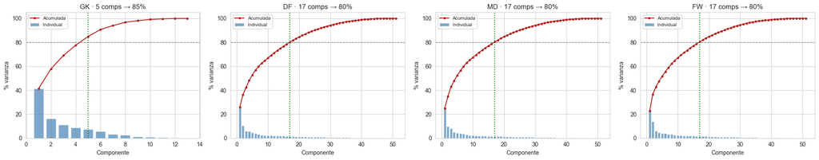

```python
# Scree plot por bloque
fig, axes = plt.subplots(1, 4, figsize=(20, 4))
for ax, b in zip(axes, BLOCKS):
    pca_full = PCA(random_state=RANDOM_STATE).fit(X_prep[b])
    var = pca_full.explained_variance_ratio_ * 100
    cum = np.cumsum(var)
    x = np.arange(1, len(var) + 1)

    ax.bar(x, var, color='steelblue', alpha=0.7, label='Individual')
    ax.plot(x, cum, 'o-', color='firebrick', ms=3, label='Acumulada')
    ax.axhline(80, ls='--', color='gray', lw=1)
    ax.axvline(n_components[b], ls=':', color='green', lw=1.5)
    ax.set_title(f"{b} · {n_components[b]} comps → {cum[n_components[b]-1]:.0f}%")
    ax.set_xlabel('Componente')
    ax.set_ylabel('% varianza')
    ax.legend(fontsize=8)
plt.tight_layout()
plt.show()
```

```python
# Cargas de las primeras componentes como ejes de estilo
def cargas_top(b, comp=0, n=8):
    load = pd.Series(pcas[b].components_[comp], index=FEATURES_BY_BLOCK[b])
    return load.reindex(load.abs().sort_values(ascending=False).index).head(n)

for b in BLOCKS:
    print(f"\n===== {b} · PC1 y PC2 (cargas dominantes) =====")
    for c in (0, 1):
        ev = pcas[b].explained_variance_ratio_[c] * 100
        print(f"\n  PC{c+1} ({ev:.1f}% var):")
        print(cargas_top(b, c).round(3).to_string())
```

```
===== GK · PC1 y PC2 (cargas dominantes) =====

  PC1 (41.4% var):
simple_passes_pct      0.401
avg_pass_distance_m   -0.386
launches_passes_pct   -0.383
pass_acc_pct           0.376
avg_action_x_m        -0.294
hand_passes_per90      0.268
goal_kicks_per90      -0.267
saves_per90           -0.241

  PC2 (16.5% var):
reflexes_per90           0.509
saves_per90              0.494
total_passes_per90       0.341
hand_passes_per90        0.335
goal_kicks_per90         0.294
gk_leaving_line_per90    0.250
high_passes_pct          0.223
launches_passes_pct     -0.166

===== DF · PC1 y PC2 (cargas dominantes) =====

  PC1 (26.0% var):
avg_action_x_m                 0.263
actions_attacking_third_pct    0.260
actions_defensive_third_pct   -0.254
throw_ins_taken_per90          0.242
crosses_passes_pct             0.239
attacking_duels_per90          0.228
shots_head_pct                -0.219
key_passes_per90               0.214

  PC2 (10.4% var):
simple_passes_pct           0.385
total_passes_per90          0.385
pass_acc_pct                0.328
launches_passes_pct        -0.308
head_passes_pct            -0.285
```

[output cut: 32 more lines]

```
total_passes_per90               0.233
shots_head_pct                  -0.212
accelerations_per90              0.208
air_duels_per90                 -0.203
touches_per90                    0.202

  PC2 (13.8% var):
avg_action_x_m                 0.281
shots_on_target_per90          0.268
actions_attacking_third_pct    0.268
shots_per90                    0.257
actions_defensive_third_pct   -0.252
clearances_per90              -0.236
interceptions_per90           -0.232
xg_per90                       0.227
```

### Composición de las componentes: diagrama de cargas

La lista de cargas dominantes identifica las variables que definen cada eje, pero no permite ver de un vistazo cómo se reparten las variables entre componentes ni cuándo una misma variable contribuye a varios ejes. El diagrama de cargas —la matriz de *loadings* del PCA representada como mapa de calor, con las variables en filas y las componentes en columnas— hace legible esa estructura: el signo y la intensidad del color expresan en qué dirección y con qué peso participa cada variable en cada componente, que es precisamente la información con la que el análisis de componentes principales construye sus ejes latentes (Tema 7).

Para mantener la lectura abordable se muestran las primeras componentes de cada bloque —las de mayor varianza, que concentran la señal de estilo— y, dentro de ellas, las variables con mayor carga en valor absoluto. La lectura confirma de forma visual la interpretación futbolística de los ejes y revela qué variables son estructurales —cargan con fuerza— y cuáles quedan relegadas, anticipando el papel del PCA como filtro objetivo señalado en la sección 1.

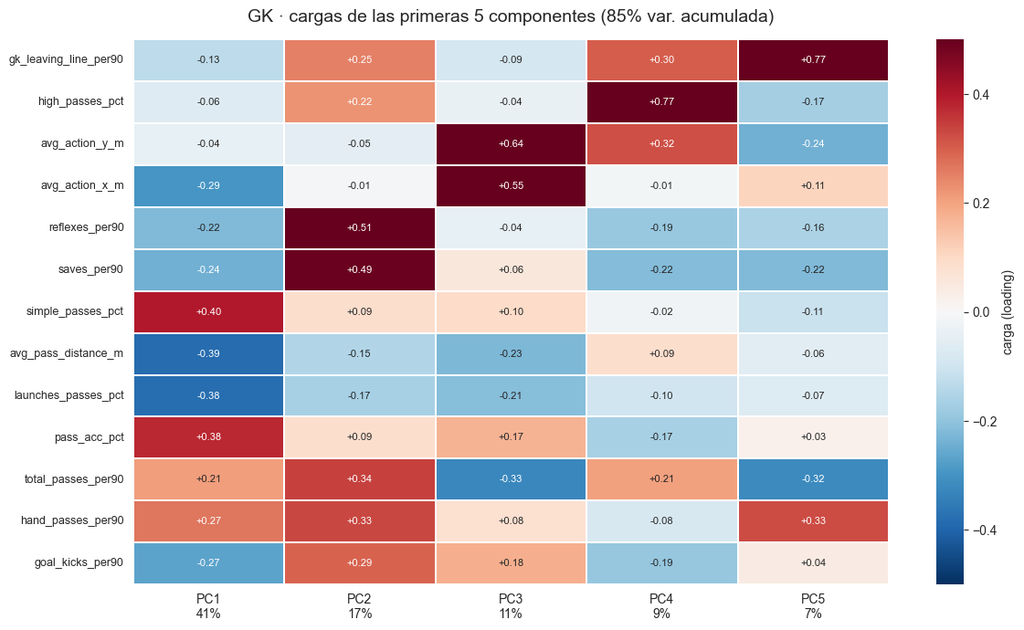

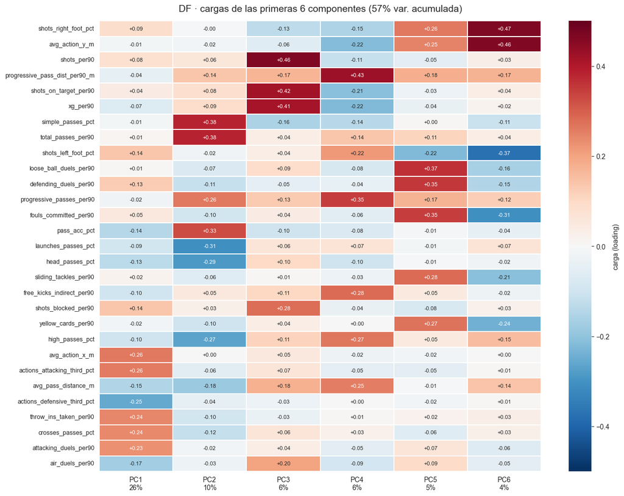

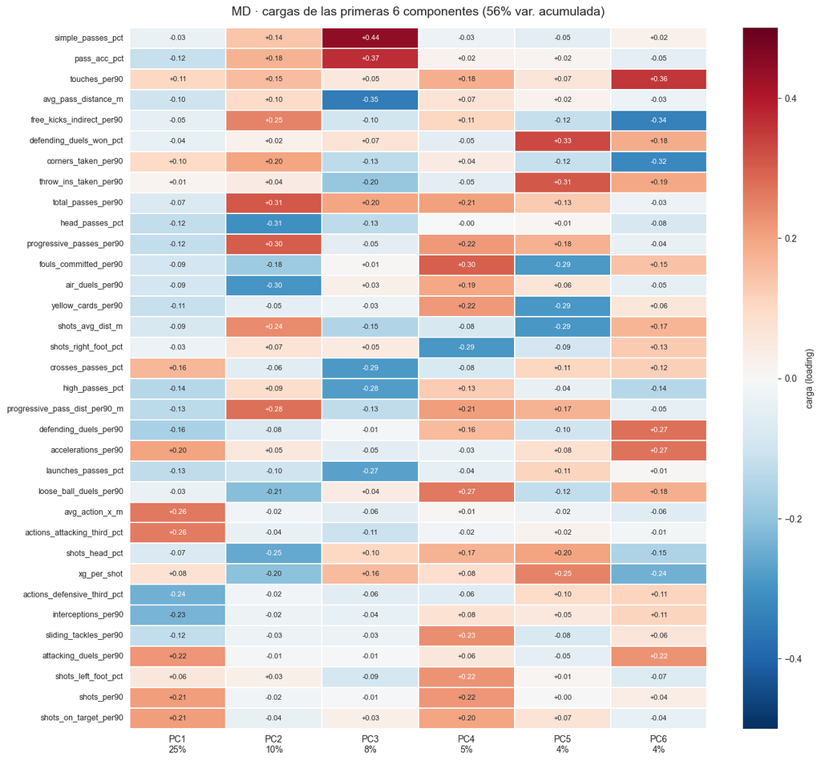

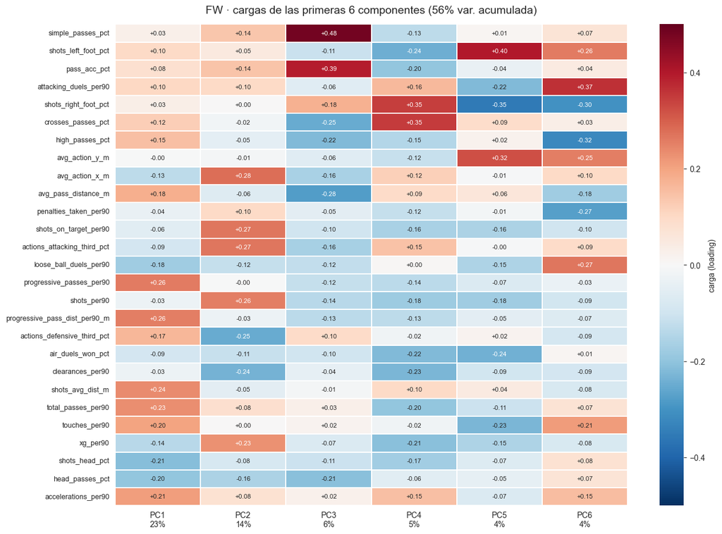

```python
# Diagrama de cargas: composición de las componentes como ejes de estilo
N_COMPS_SHOW = {b: min(6, n_components[b]) for b in BLOCKS}
TOP_PER_COMP = 6

for b in BLOCKS:
    feats = FEATURES_BY_BLOCK[b]
    nc = N_COMPS_SHOW[b]

    L = pd.DataFrame(
        pcas[b].components_[:nc].T,
        index=feats,
        columns=[f"PC{i+1}" for i in range(nc)]
    )

    sel = set()
    for c in L.columns:
        sel |= set(L[c].abs().sort_values(ascending=False).head(TOP_PER_COMP).index)

    sel = sorted(sel, key=lambda f: -L.loc[f].abs().max())
    M = L.loc[sel]

    var = pcas[b].explained_variance_ratio_[:nc] * 100
    M.columns = [f"PC{i+1}\n{var[i]:.0f}%" for i in range(nc)]

    fig_height = max(7, 0.35 * len(M))
    fig_width = max(10, 1.4 * nc + 5)

    plt.figure(figsize=(fig_width, fig_height))
    ax = sns.heatmap(
        M,
        cmap="RdBu_r",
        center=0,
        vmin=-0.5,
        vmax=0.5,
        annot=True,
        fmt="+.2f",
        annot_kws={"size": 8},
        cbar_kws={"label": "carga (loading)"},
        linewidths=0.3,
        linecolor="white"
    )

    ax.set_title(
        f"{b} · cargas de las primeras {nc} componentes "
        f"({var[:nc].sum():.0f}% var. acumulada)",
        fontsize=14,
        pad=14
    )
    ax.set_xlabel("")
    ax.set_ylabel("")
    ax.tick_params(axis="x", labelsize=10)
    ax.tick_params(axis="y", labelsize=9)

    plt.tight_layout()
    plt.show()
```

### Lectura del diagrama de cargas

El diagrama confirma de un vistazo la asimetría estructural entre porteros y jugadores de campo y, sobre todo, hace visible cómo se reparte el estilo entre los ejes latentes.

En porteros, la primera componente —el 41 % de la varianza— es un eje limpio y aislado: opone la distribución corta y precisa (`simple_passes_pct` +0,40, `pass_acc_pct` +0,38) al juego directo (`avg_pass_distance_m` −0,39, `launches_passes_pct` −0,38). Es el eje que separa al portero moderno de salida del portero clásico de despeje largo, y su nitidez —ninguna otra variable lo contamina— retrata el carácter casi unidimensional del bloque. Las componentes siguientes recogen facetas secundarias y bien separadas: la carga de trabajo defensivo (`reflexes_per90` +0,51, `saves_per90` +0,49 en PC2), la posición media sobre el campo (`avg_action_y_m`, `avg_action_x_m` en PC3) y el juego aéreo de distribución (`high_passes_pct` +0,77 en PC4).

Estos ejes son el espacio sobre el que operará el agrupamiento y, más adelante, el motor de similitud: proyectados sobre las componentes principales, dos jugadores son tanto más parecidos cuanto más próximos quedan en este sistema de coordenadas de estilo.

### Biplot: jugadores y variables en el mismo plano

El diagrama de cargas describe las componentes una a una; el biplot las pone en relación. Es la representación canónica del PCA (Tema 7): superpone en un mismo plano la proyección de los jugadores sobre las dos primeras componentes —cada punto es un futbolista— y los vectores de carga de las variables —cada flecha, una variable—. La dirección de una flecha indica hacia qué zona del plano empuja esa variable, su longitud cuánto pesa en estas dos componentes, y el ángulo entre dos flechas aproxima su correlación: flechas alineadas miden facetas afines, opuestas miden polos contrarios, perpendiculares son independientes. Leer dónde cae un jugador respecto a las flechas permite, por tanto, interpretar su estilo directamente sobre la nube.

Se representa el plano PC1–PC2 de cada bloque, las dos componentes de mayor varianza. Sobre porteros, donde la primera componente domina, el plano captura casi toda la identidad de estilo; sobre los bloques de campo, multidimensionales, las dos primeras componentes son solo una ventana parcial —recogen entre un tercio y un 37 % de la varianza— pero suficiente para visualizar los ejes principales y el carácter continuo de la distribución.

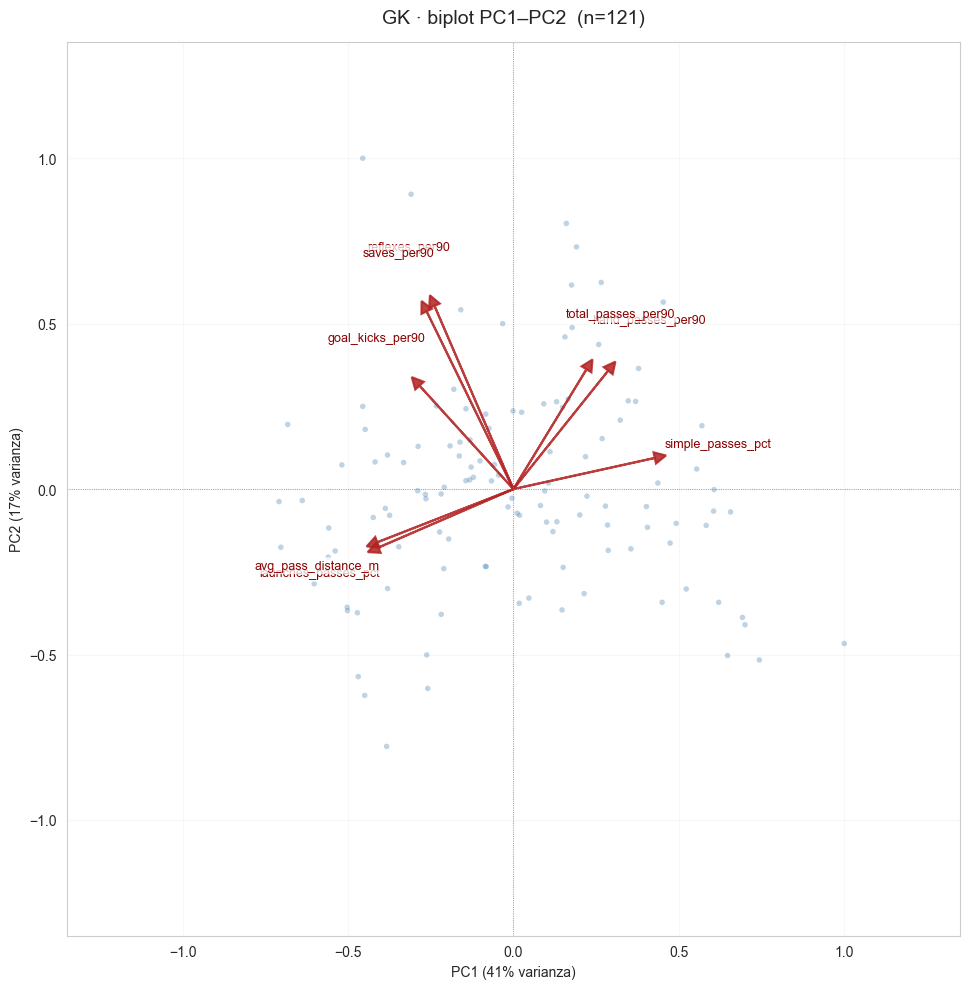

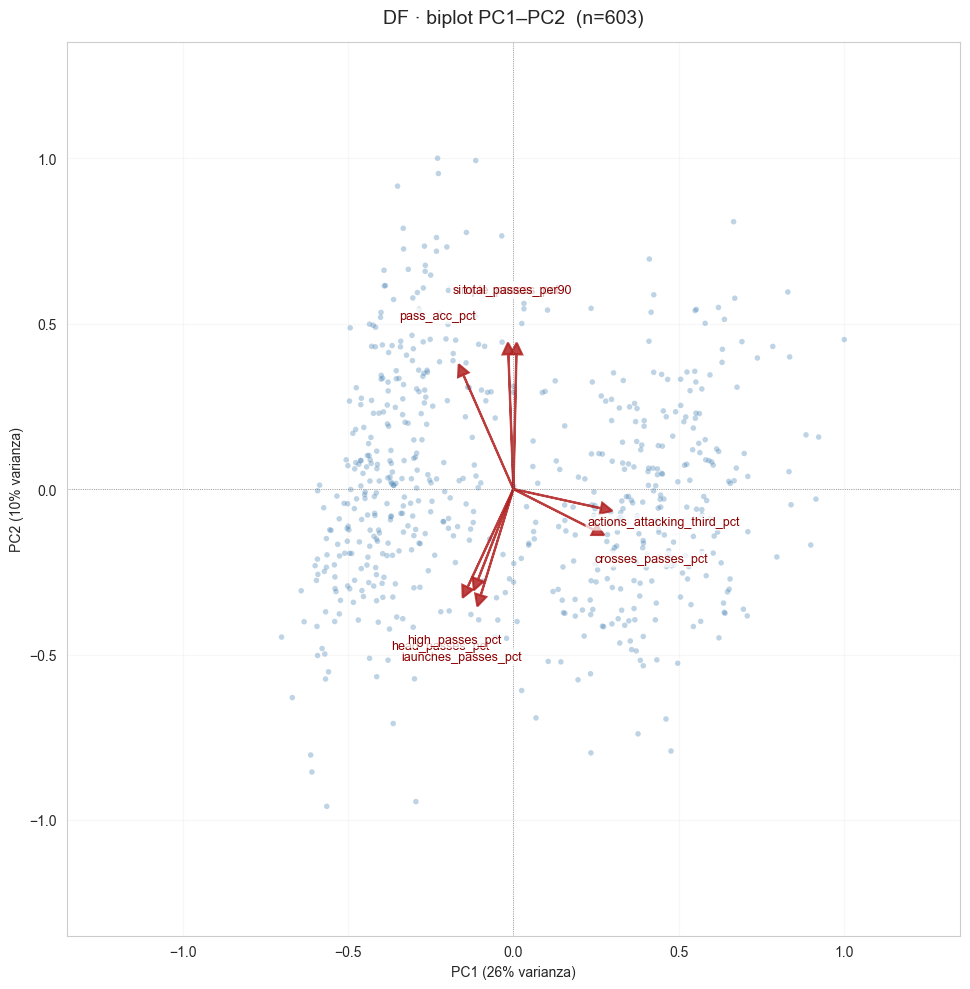

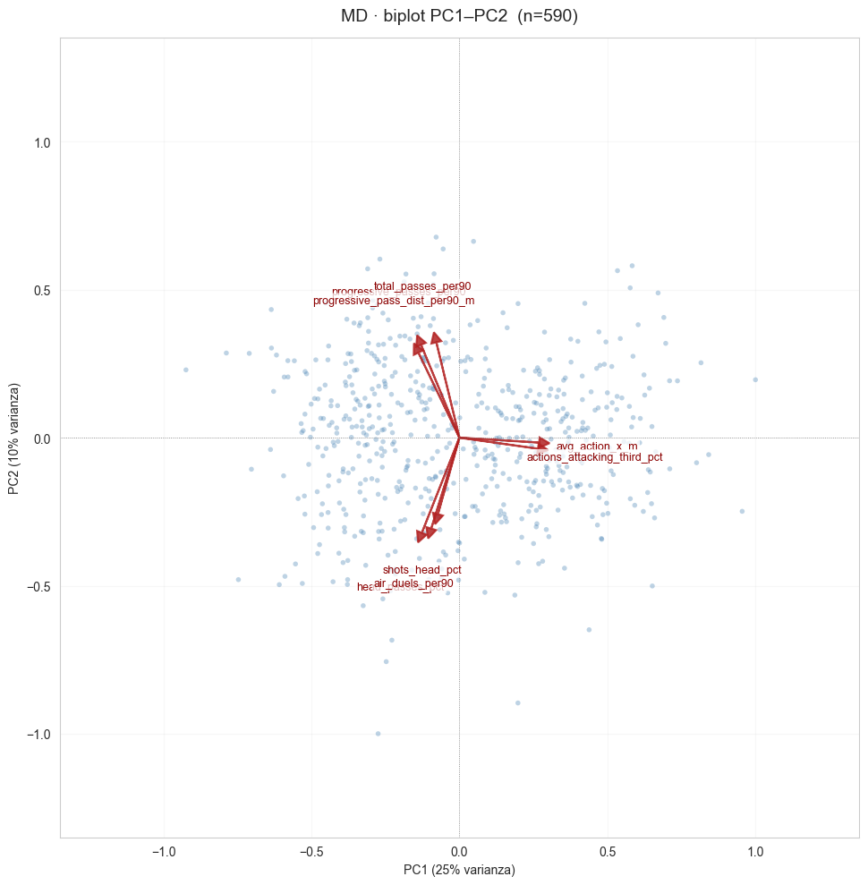

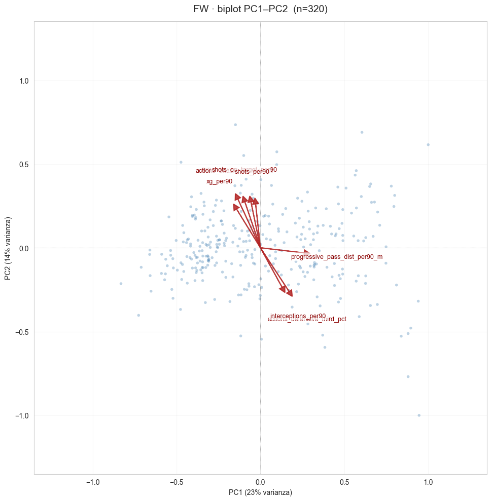

```python
# Biplot PC1–PC2 por bloque: jugadores (puntos) y cargas de variables (vectores)
N_ARROWS = 8

for b in BLOCKS:
    feats = FEATURES_BY_BLOCK[b]
    scores = X_pca[b][:, :2]
    var = pcas[b].explained_variance_ratio_[:2] * 100

    # Escalado de scores para representar jugadores y cargas en el mismo plano
    s = scores / np.abs(scores).max(axis=0)

    fig, ax = plt.subplots(figsize=(12, 10))

    ax.scatter(
        s[:, 0],
        s[:, 1],
        s=16,
        c='steelblue',
        alpha=0.35,
        edgecolors='none'
    )

    # Vectores de carga: variables con mayor peso conjunto en PC1-PC2
    load = pcas[b].components_[:2].T
    norm = np.linalg.norm(load, axis=1)
    idx = np.argsort(-norm)[:N_ARROWS]

    arrow_scale = 1.15

    for i in idx:
        x = load[i, 0] * arrow_scale
        y = load[i, 1] * arrow_scale

        ax.arrow(
            0,
            0,
            x,
            y,
            color='firebrick',
            alpha=0.85,
            head_width=0.035,
            head_length=0.035,
            length_includes_head=True,
            lw=1.5
        )

        r = np.hypot(x, y)
        ox, oy = (x / r) * 0.16, (y / r) * 0.16

        ax.text(
            x + ox,
            y + oy,
            feats[i],
            color='darkred',
            fontsize=9,
            ha='center',
            va='center',
            bbox=dict(
                boxstyle='round,pad=0.18',
                fc='white',
                ec='none',
                alpha=0.75
            )
        )

    lim = 1.35
    ax.set_xlim(-lim, lim)
    ax.set_ylim(-lim, lim)

    ax.axhline(0, color='gray', lw=0.6, ls=':')
    ax.axvline(0, color='gray', lw=0.6, ls=':')

    ax.set_xlabel(f"PC1 ({var[0]:.0f}% varianza)")
    ax.set_ylabel(f"PC2 ({var[1]:.0f}% varianza)")
    ax.set_title(f"{b} · biplot PC1–PC2  (n={len(scores)})", fontsize=14, pad=14)

    ax.grid(alpha=0.15)
    ax.set_aspect('equal', adjustable='box')

    plt.tight_layout()
    plt.show()
```

## 4. Selección del número de clústers por bloque

Con los datos proyectados sobre las componentes principales, resta decidir cuántos grupos —cuántos arquetipos de estilo— estructuran cada bloque. *K-Means* exige fijar de antemano ese número, *k*, y la decisión se toma sin recurrir a reglas arbitrarias sobre el tamaño de los grupos, sino mediante dos criterios complementarios recogidos en los materiales de agrupamiento del proyecto.

El primero es el **método del codo**: a medida que aumenta *k*, la inercia —la suma de distancias al cuadrado de cada punto a su centroide— decrece de forma monótona, pero el ritmo de mejora se atenúa; el «codo» de la curva señala el punto a partir del cual añadir grupos apenas reduce la dispersión interna. El segundo es el **coeficiente de silueta**, que mide para cada *k* cómo de compactos y separados quedan los grupos, en un rango de −1 a 1; valores más altos indican una partición más limpia.

Ninguno de los dos criterios es decisorio por sí solo —el codo es a menudo ambiguo y la silueta tiende a premiar particiones gruesas—, de modo que se interpretan conjuntamente y se contrastan con el sentido futbolístico: una partición es preferible cuando, además de ser sólida en las métricas, produce arquetipos reconocibles. El barrido se realiza de forma independiente en cada bloque, sobre su propio espacio de componentes principales.

A estos dos criterios internos se añade una comprobación sobre la propia naturaleza de la estructura: antes de fijar un número de grupos conviene verificar si el espacio de estilo presenta realmente cortes naturales. La sección corrobora por ello el diagnóstico con dos métodos independientes de *K-Means*, el agrupamiento jerárquico y un modelo de mezcla gaussiana, cuya concordancia refuerza la lectura del resultado.

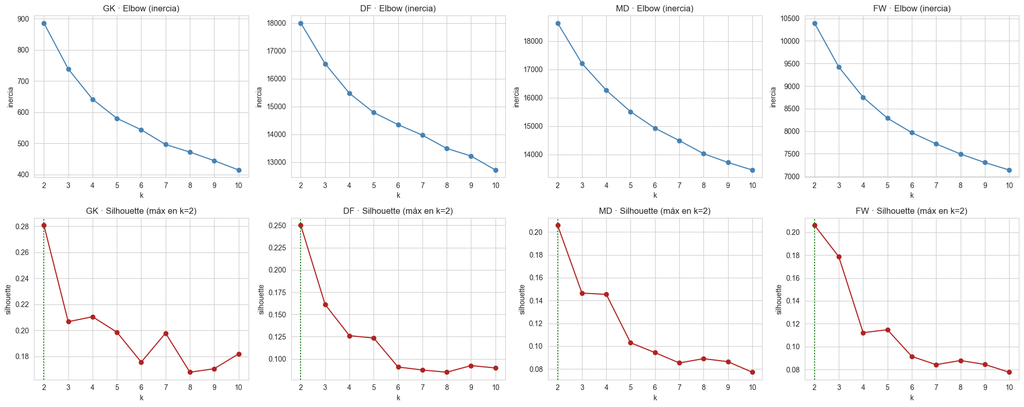

```
===== GK =====
 k  inertia  silhouette
 2  886.262       0.281
 3  738.728       0.207
 4  641.558       0.210
 5  580.132       0.199
 6  543.404       0.175
 7  496.250       0.198
 8  471.854       0.168
 9  444.315       0.171
10  414.435       0.182

===== DF =====
 k    inertia  silhouette
 2 17,999.581       0.250
```

[output cut: 32 more lines]

```python
# Barrido de k por bloque: inercia (Elbow) y coeficiente de silueta
K_RANGE = range(2, 11)
seleccion = {}

fig, axes = plt.subplots(2, 4, figsize=(20, 8))
for j, b in enumerate(BLOCKS):
    X = X_pca[b]
    inertias, sils = [], []
    for k in K_RANGE:
        km = KMeans(n_clusters=k, n_init=10, random_state=RANDOM_STATE).fit(X)
        inertias.append(km.inertia_)
        sils.append(silhouette_score(X, km.labels_))
    seleccion[b] = pd.DataFrame({'k': list(K_RANGE), 'inertia': inertias, 'silhouette': sils})
    k_best = int(seleccion[b].loc[seleccion[b]['silhouette'].idxmax(), 'k'])

    axes[0, j].plot(list(K_RANGE), inertias, 'o-', color='steelblue')
    axes[0, j].set_title(f"{b} · Elbow (inercia)")
    axes[0, j].set_xlabel('k'); axes[0, j].set_ylabel('inercia')

    axes[1, j].plot(list(K_RANGE), sils, 'o-', color='firebrick')
    axes[1, j].axvline(k_best, ls=':', color='green', lw=1.5)
    axes[1, j].set_title(f"{b} · Silhouette (máx en k={k_best})")
    axes[1, j].set_xlabel('k'); axes[1, j].set_ylabel('silhouette')
plt.tight_layout()
plt.show()

for b in BLOCKS:
    print(f"\n===== {b} =====")
    print(seleccion[b].round(4).to_string(index=False))
```

### Lectura del barrido: un continuo de estilo, no grumos separados

El barrido arroja un patrón uniforme en los cuatro bloques: la silueta es máxima en k=2 y decrece después, mientras la inercia desciende de forma suave, sin codo pronunciado. Lejos de ser un resultado fallido, esta regularidad es en sí misma el principal hallazgo de la sección.

Los valores absolutos de silueta son bajos —0,28 en porteros, 0,25 en defensas, 0,21 en centrocampistas y delanteros—; ninguno alcanza el umbral de estructura «razonable» (0,51) de las bandas habituales de interpretación (Kaufman & Rousseeuw, 1990). El estilo de juego dentro de una misma posición no se organiza en grupos compactos y separados, sino que se distribuye sobre un continuo, coherente con la naturaleza del fútbol, donde los perfiles se solapan de forma gradual. Que la silueta prefiera la partición más gruesa es consecuencia directa de ello: sobre datos sin separación natural, subdividir incrementa el solapamiento entre grupos vecinos y deprime la métrica; el máximo en k=2 no revela dos tipos naturales, sino el corte por el eje de mayor varianza, de escaso valor descriptivo.

Este comportamiento tiene una explicación teórica en los fundamentos del propio algoritmo: K-Means asume grupos de geometría esférica y, según se recoge en los materiales de la asignatura, no reconoce estructuras de geometría alargada o compleja. Un continuo de estilo es precisamente una estructura alargada, de modo que la ausencia de codo y la silueta baja son la respuesta esperable del método ante este tipo de datos, y no un defecto de la implementación.

### Selección de k ante un codo ambiguo

La ausencia de un codo nítido no es excepcional: los propios materiales de la asignatura advierten de que la elección de k a veces es clara y otras no lo es, en cuyo caso la decisión se traslada al criterio del analista. La literatura es aún más enfática —se ha documentado que el método del codo carece de soporte teórico sólido y que, sobre datos sin estructura real, la curva de inercia sigue la razón 1/k y puede inducir a identificar un codo inexistente (Schubert, 2022)—. Forzar una rodilla donde no la hay sería, por tanto, un error metodológico.

Antes de trasladar la decisión, un control gráfico complementario —recogido también en los materiales de la asignatura— permite inspeccionar visualmente la estructura: la matriz de disimilaridad ordenada por clústeres.

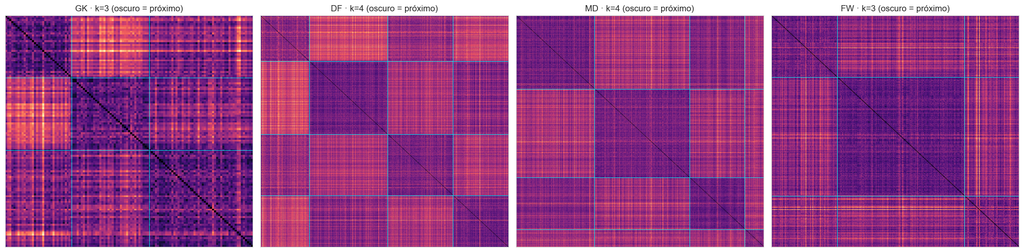

```python
# Matriz de disimilaridad ordenada por clústeres (control gráfico)
from sklearn.metrics import pairwise_distances

k_viz = {'GK': 3, 'DF': 4, 'MD': 4, 'FW': 3}

fig, axes = plt.subplots(1, 4, figsize=(20, 5))
for ax, b in zip(axes, BLOCKS):
    X = X_pca[b]
    labels = KMeans(n_clusters=k_viz[b], n_init=10,
                    random_state=RANDOM_STATE).fit_predict(X)
    order = np.argsort(labels)
    D = pairwise_distances(X[order], metric='euclidean')
    im = ax.imshow(D, cmap='magma', aspect='auto')
    bounds = np.cumsum(np.bincount(labels))[:-1]
    for bnd in bounds:
        ax.axhline(bnd, color='cyan', lw=0.6)
        ax.axvline(bnd, color='cyan', lw=0.6)
    ax.set_title(f"{b} · k={k_viz[b]} (oscuro = próximo)")
    ax.set_xticks([]); ax.set_yticks([])
plt.tight_layout()
plt.show()
```

La matriz de disimilaridad confirma de forma gráfica el diagnóstico del barrido y lo matiza en una dirección útil. En los cuatro bloques, los cuadros situados sobre la diagonal, que agrupan a jugadores asignados a un mismo clúster, presentan distancias menores que las regiones fuera de la diagonal: la partición no es arbitraria, sino que separa regiones del espacio internamente más homogéneas. Existe, por tanto, estructura aprovechable. Pero esa estructura es blanda: las fronteras entre bloques no son limpias, sino que se difuminan en un degradado continuo, y aparecen bandas brillantes que recorren filas y columnas completas, correspondientes a jugadores de perfil singular que quedan lejos de prácticamente todos los demás.

El bloque de porteros exhibe la separación más marcada —un subgrupo claramente diferenciado del resto—, en consonancia con su estructura de componentes casi unidimensional. Los bloques de campo muestran cuadros diagonales reconocibles pero con mayor solapamiento, especialmente acusado en delanteros. La conclusión refuerza la decisión metodológica de la sección: el agrupamiento es válido como segmentación descriptiva —discretiza un continuo en regiones coherentes y nombrables—, y no como descubrimiento de tipos naturales aislados. La elección del número de grupos, por tanto, se resuelve por la interpretabilidad de los arquetipos resultantes, que es lo que aborda la sección siguiente.

### Corroboración con clustering jerárquico (enlace de Ward)

El barrido y la matriz de disimilaridad apuntan a un espacio sin fronteras nítidas, pero ambos descansan en *K-Means*. Para comprobar que la conclusión no depende del algoritmo se recurre a una segunda familia, el **agrupamiento jerárquico aglomerativo**, sobre el mismo espacio de componentes principales y con **enlace de Ward**, que en cada paso fusiona los conglomerados que menos incrementan la varianza interna, el criterio más afín a la lógica de *K-Means*. El dendrograma muestra la jerarquía completa de fusiones: un salto de altura dominante antes de las últimas uniones delataría un número natural de grupos; su ausencia, una estructura continua.

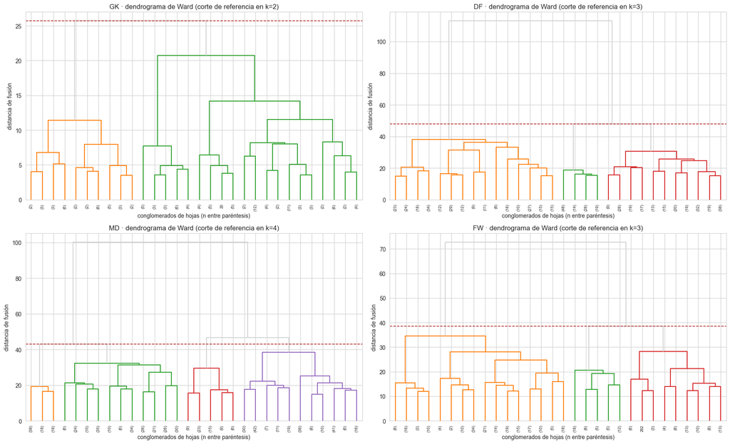

```
Altura de las 6 últimas fusiones por bloque (descenso gradual ⇒ sin salto dominante que imponga un k):
  GK:   25.7    20.7    14.1    11.5    11.4     8.3
  DF:  113.1    48.0    38.2    36.2    33.3    31.5
  MD:  100.2    46.7    43.0    38.4    32.2    31.5
  FW:   72.8    38.5    34.6    28.3    28.1    24.8
```

```python
# clustering jerárquico aglomerativo (enlace de Ward) por bloque
from scipy.cluster.hierarchy import linkage, dendrogram

k_ref = {'GK': 2, 'DF': 3, 'MD': 4, 'FW': 3}                       # k de referencia, solo sitúa el corte
Z_ward = {b: linkage(X_pca[b], method='ward') for b in BLOCKS}    # mismo espacio PCA, métrica euclídea que K-Means

fig, axes = plt.subplots(2, 2, figsize=(18, 11))
for ax, b in zip(axes.ravel(), BLOCKS):
    Z, k = Z_ward[b], k_ref[b]
    ct = Z[-(k - 1), 2] - 1e-9                                     # umbral que deja k ramas coloreadas
    dendrogram(Z, ax=ax, truncate_mode='lastp', p=30, color_threshold=ct,
               above_threshold_color='lightgray', show_leaf_counts=True,
               leaf_rotation=90, leaf_font_size=7)
    ax.axhline(ct, ls='--', color='firebrick', lw=1.2)
    ax.set_title(f"{b} · dendrograma de Ward (corte de referencia en k={k})", fontsize=12)
    ax.set_ylabel("distancia de fusión")
    ax.set_xlabel("conglomerados de hojas (n entre paréntesis)")
plt.tight_layout()
plt.show()

print("Altura de las 6 últimas fusiones por bloque (descenso gradual ⇒ sin salto dominante que imponga un k):")
for b in BLOCKS:
    tops = Z_ward[b][-6:, 2][::-1]
    print(f"  {b}: " + "  ".join(f"{h:6.1f}" for h in tops))
```

### Lectura del dendrograma

El agrupamiento jerárquico, de una familia distinta a *K-Means*, corrobora el diagnóstico. En los cuatro bloques, la única altura de fusión claramente destacada es la raíz del árbol (113 en defensas, 100 en centrocampistas, 73 en delanteros, frente a las ~40 de la fusión siguiente); por debajo de ella las uniones descienden de forma gradual, sin un segundo salto que aísle un número natural de grupos. El árbol reconoce, a lo sumo, una partición binaria gruesa, el eje principal de variación, que el PCA identificó como posicional, la misma que la silueta premiaba en *k*=2.

En porteros el salto superior es más tenue (25,7 frente a 20,7) y el árbol más equilibrado, coherente con su estructura casi unidimensional. El corte de referencia (línea roja) se sitúa en el *k* que se perfilará en la sección 5 solo para visualizar cómo se formarían los grupos; el propio dendrograma no señala esa altura como especial. Que dos métodos independientes: partición y jerarquía, coincidan en no hallar fronteras naturales más allá de un corte grueso es, hasta aquí, la confirmación más sólida del carácter continuo del espacio de estilo.

### Selección del número de componentes desde un marco probabilístico (mezcla gaussiana)

Las tres vías anteriores descansan en distancias; el modelo de mezcla gaussiana aborda la cuestión desde la probabilidad. Modela cada bloque como una **mezcla de distribuciones gaussianas** ajustada por el algoritmo de **esperanza-maximización** (Tema 6) y permite preguntar, mediante criterios de información, cuántas componentes respaldan los datos. Una alternativa intuitiva sería leer el solapamiento en las pertenencias *a posteriori* de cada jugador, pero en un espacio de dimensión alta esas pertenencias saturan hacia asignaciones casi duras —un artefacto conocido de la covarianza completa, no una señal de separación real—, de modo que no son una medida fiable del continuo. La vía rigurosa es el **criterio de información bayesiano (BIC)**, que compara modelos penalizando su complejidad: su mínimo señala el número de componentes que el modelo respalda, y un mínimo temprano y poco profundo indica que ningún número de grupos se impone sobre el resto.

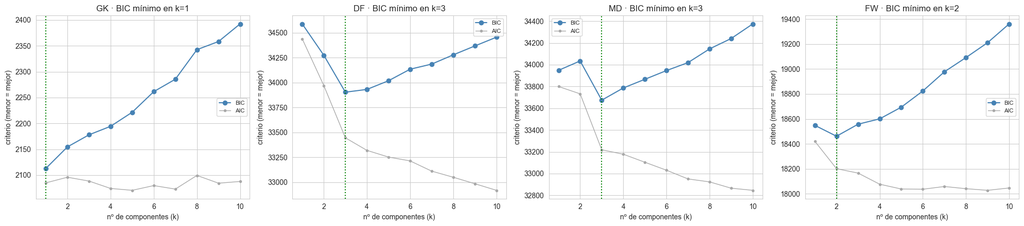

```
k con BIC mínimo por bloque (curva plana o mínimo en k alto ⇒ ningún nº de grupos se impone):
  GK: k_BIC = 1
  DF: k_BIC = 3
  MD: k_BIC = 3
  FW: k_BIC = 2
```

```python
# Selección del nº de componentes de la mezcla gaussiana por BIC/AIC
from sklearn.mixture import GaussianMixture

K_RANGE_GMM = range(1, 11)

fig, axes = plt.subplots(1, 4, figsize=(20, 4.5))
sel_bic = {}
for ax, b in zip(axes, BLOCKS):
    X = X_pca[b]
    bics, aics = [], []
    for k in K_RANGE_GMM:
        g = GaussianMixture(n_components=k, covariance_type='diag',   # parsimoniosa: BIC interpretable en dim. alta
                            n_init=5, random_state=RANDOM_STATE).fit(X)
        bics.append(g.bic(X)); aics.append(g.aic(X))
    k_bic = list(K_RANGE_GMM)[int(np.argmin(bics))]
    sel_bic[b] = k_bic
    ax.plot(list(K_RANGE_GMM), bics, 'o-', color='steelblue', label='BIC')
    ax.plot(list(K_RANGE_GMM), aics, 'o-', color='darkgray', lw=1, ms=3, label='AIC')
    ax.axvline(k_bic, ls=':', color='green', lw=1.5)
    ax.set_title(f"{b} · BIC mínimo en k={k_bic}")
    ax.set_xlabel('nº de componentes (k)'); ax.set_ylabel('criterio (menor = mejor)')
    ax.legend(fontsize=8)
plt.tight_layout(); plt.show()

print("k con BIC mínimo por bloque (curva plana o mínimo en k alto ⇒ ningún nº de grupos se impone):")
for b in BLOCKS:
    print(f"  {b}: k_BIC = {sel_bic[b]}")
```

### Lectura del BIC y cierre de la sección

Que el óptimo de densidad se sitúe incluso por debajo del número de arquetipos que se adoptará en §5 no contradice esa elección, sino que la fundamenta. El BIC responde a cuántas distribuciones bastan para describir la densidad del bloque —y la respuesta, *muy pocas*, es precisamente la del continuo—; el número de estilos, en cambio, no se decide por densidad sino por la interpretabilidad futbolística de los grupos, según el criterio fijado al inicio de esta sección y avalado por la práctica del scouting (Pappalardo et al., 2019). El óptimo estadístico marca el suelo —la estructura mínima que los datos imponen—; sobre él, la segmentación añade el detalle que la lectura táctica requiere.

Cuatro vías independientes convergen así en una misma conclusión: el coeficiente de silueta, máximo en una partición gruesa y bajo en términos absolutos; la matriz de disimilaridad, de fronteras difuminadas; el dendrograma jerárquico, sin un segundo salto de fusión que aísle grupos naturales; y la mezcla gaussiana, cuyo BIC respalda muy pocas componentes. El estilo de juego, dentro de una misma posición, se distribuye sobre un **continuo** y no en tipos discretos y aislados. Esta constatación, fundamentada en cuatro métodos y en las limitaciones de *K-Means*, reorienta el papel del agrupamiento: no es un fin que descubra tipos ocultos, sino una capa descriptiva que discretiza ese continuo en un vocabulario manejable de estilos. En consecuencia, la elección del número de grupos se traslada a la sección siguiente, donde se resuelve, preseleccionando dos candidatos por bloque, por la calidad e independencia de los arquetipos resultantes y no por una métrica interna.

## 5. Agrupamiento y perfilado de arquetipos

Establecido que el número de grupos debe decidirse por la interpretabilidad de los arquetipos, esta sección ejecuta K-Means sobre el espacio de componentes principales de cada bloque para los valores de k preseleccionados —dos por bloque, dentro del rango que las métricas internas no descartan— y perfila cada partición resultante. El algoritmo se inicializa diez veces (`n_init=10`) y se retiene la mejor solución, lo que mitiga la dependencia del resultado respecto a la configuración inicial de los centroides, una limitación conocida del método.

```python
# Ajuste de K-Means para los k candidatos por bloque
CANDIDATES = {'GK': [2, 3], 'DF': [3, 4], 'MD': [3, 4], 'FW': [3, 4]}

models, labels_cand = {}, {}
for b in BLOCKS:
    for k in CANDIDATES[b]:
        km = KMeans(n_clusters=k, n_init=10, random_state=RANDOM_STATE).fit(X_pca[b])
        models[(b, k)] = km
        labels_cand[(b, k)] = km.labels_
    print(f"  {b}: ajustados k ∈ {CANDIDATES[b]}")
```

```
  GK: ajustados k ∈ [2, 3]
  DF: ajustados k ∈ [3, 4]
  MD: ajustados k ∈ [3, 4]
  FW: ajustados k ∈ [3, 4]
```

```python
# Perfilado de las particiones candidatas
def perfilar(b, k, n_top=4, n_repr=4):
    feats = FEATURES_BY_BLOCK[b]
    lab = labels_cand[(b, k)]
    Xz = pd.DataFrame(X_prep[b], columns=feats)
    Xz['cluster'] = lab
    z_means = Xz.groupby('cluster')[feats].mean()

    print(f"\n{'='*64}\n{b} · k={k}\n{'='*64}")
    for c in range(k):
        mask = lab == c
        g = blocks[b][mask]
        z = z_means.loc[c].sort_values()
        altos = ", ".join(f"{f} ({z[f]:+.1f})" for f in z.tail(n_top).index[::-1])
        bajos = ", ".join(f"{f} ({z[f]:+.1f})" for f in z.head(n_top).index)

        centroide = models[(b, k)].cluster_centers_[c]
        d = np.linalg.norm(X_pca[b][mask] - centroide, axis=1)
        sub_ids = ids[b].loc[mask].reset_index(drop=True)
        repr_players = sub_ids.iloc[np.argsort(d)[:n_repr]]['short_name'].tolist()

        print(f"\n  Cluster {c} · n={int(mask.sum())} · "
              f"goals/90={g['goals_per90'].mean():.2f} · "
              f"G−xG={g['goals_minus_xg'].mean():+.2f}")
        print(f"    ↑ {altos}")
        print(f"    ↓ {bajos}")
        print(f"    repr: {', '.join(repr_players)}")

for b in BLOCKS:
    for k in CANDIDATES[b]:
        perfilar(b, k)
```

```
================================================================
GK · k=2
================================================================

  Cluster 0 · n=67 · goals/90=0.00 · G−xG=+0.00
    ↑ avg_pass_distance_m (+0.7), launches_passes_pct (+0.7), avg_action_x_m (+0.5), goal_kicks_per90 (+0.5)
    ↓ simple_passes_pct (-0.7), pass_acc_pct (-0.6), hand_passes_per90 (-0.5), total_passes_per90 (-0.5)
    repr: R. Gurtner, A. Oukidja, M. Ryan, Y. Bounou

  Cluster 1 · n=54 · goals/90=0.00 · G−xG=-0.01
    ↑ simple_passes_pct (+0.8), pass_acc_pct (+0.8), hand_passes_per90 (+0.7), total_passes_per90 (+0.6)
    ↓ avg_pass_distance_m (-0.8), launches_passes_pct (-0.8), avg_action_x_m (-0.7), goal_kicks_per90 (-0.6)
    repr: A. Lopes, L. Hradecky, P. Gulácsi, R. Bürki

================================================================
GK · k=3
================================================================

  Cluster 0 · n=32 · goals/90=0.00 · G−xG=+0.00
    ↑ simple_passes_pct (+1.2), pass_acc_pct (+1.0), hand_passes_per90 (+0.6), total_passes_per90 (+0.5)
    ↓ launches_passes_pct (-1.0), avg_pass_distance_m (-1.0), goal_kicks_per90 (-1.0), avg_action_x_m (-0.9)
    repr: A. Lopes, B. Leno, Alisson, H. Lloris

  Cluster 1 · n=38 · goals/90=0.00 · G−xG=-0.01
    ↑ avg_pass_distance_m (+1.1), launches_passes_pct (+1.1), avg_action_x_m (+0.7), goal_kicks_per90 (+0.4)
    ↓ pass_acc_pct (-1.1), hand_passes_per90 (-1.0), simple_passes_pct (-1.0), total_passes_per90 (-0.7)
    repr: Y. Bounou, R. Gurtner, F. Forster, M. Ryan

  Cluster 2 · n=51 · goals/90=0.00 · G−xG=-0.00
    ↑ hand_passes_per90 (+0.4), gk_leaving_line_per90 (+0.4), saves_per90 (+0.4), goal_kicks_per90 (+0.3)
    ↓ avg_pass_distance_m (-0.2), launches_passes_pct (-0.2), simple_passes_pct (+0.0), avg_action_x_m (+0.0)
    repr: A. Mirante, K. Johnsson, R. Zentner, J. Pavlenka

================================================================
DF · k=3
================================================================

  Cluster 0 · n=262 · goals/90=0.03 · G−xG=-0.07
    ↑ actions_attacking_third_pct (+1.0), avg_action_x_m (+1.0), throw_ins_taken_per90 (+1.0), crosses_passes_pct (+0.9)
    ↓ actions_defensive_third_pct (-1.0), shots_head_pct (-0.8), clearances_per90 (-0.7), pass_acc_pct (-0.7)
```

[output cut: 106 more lines]

```

  Cluster 1 · n=66 · goals/90=0.15 · G−xG=-0.18
    ↑ actions_defensive_third_pct (+1.4), defending_duels_per90 (+1.3), interceptions_per90 (+1.1), shots_avg_dist_m (+1.0)
    ↓ avg_action_x_m (-1.2), xg_per_shot (-1.0), xg_per90 (-1.0), actions_attacking_third_pct (-1.0)
    repr: S. Grandsir, N. de Préville, I. Bebou, E. Choupo-Moting

  Cluster 2 · n=55 · goals/90=0.34 · G−xG=+1.72
    ↑ corners_taken_per90 (+1.4), total_passes_per90 (+1.4), key_passes_per90 (+1.3), progressive_passes_per90 (+1.2)
    ↓ fouls_committed_per90 (-0.9), air_duels_per90 (-0.9), loose_ball_duels_per90 (-0.9), head_passes_pct (-0.9)
    repr: A. Schürrle, A. Yarmolenko, E. Hazard, A. El Ghazi

  Cluster 3 · n=98 · goals/90=0.40 · G−xG=+0.73
    ↑ xg_per90 (+0.7), avg_action_x_m (+0.6), actions_attacking_third_pct (+0.6), shots_on_target_per90 (+0.5)
    ↓ interceptions_per90 (-0.6), progressive_pass_dist_per90_m (-0.5), actions_defensive_third_pct (-0.5), progressive_passes_per90 (-0.5)
    repr: G. Simeone, K. Toko Ekambi, T. Abraham, R. Falcao
```

### Selección del número de grupos por bloque

El perfilado de las particiones candidatas permite resolver la elección de k por la calidad e independencia de los arquetipos, según el criterio fijado en la sección 4. La decisión es distinta en cada bloque, lo que confirma que el número de estilos no es una constante a imponer, sino una propiedad de los datos de cada posición.

En **porteros** se retienen dos grupos. Su espacio, casi unidimensional, opone con nitidez al guardameta de construcción —distribución corta y precisa, salida de balón con la mano— frente al de juego directo —lanzamientos largos, mayor distancia de pase, saques de puerta—. La partición en tres grupos no añade un tercer estilo, sino que fragmenta el continuo: el grupo adicional presenta cargas mínimas (inferiores a media desviación), propias del centro indiferenciado de la distribución y no de una identidad propia.

En **defensas** se retienen tres grupos, que reproducen la taxonomía clásica de la posición: el lateral ofensivo —posición adelantada y ancha, centros, saques de banda—, el central de salida —volumen y precisión de pase, progresión— y el central de contención —despejes, juego aéreo, acciones en el tercio defensivo—. La partición en cuatro grupos solo subdivide a los laterales en dos perfiles anchos parcialmente solapados, a costa de una pérdida apreciable de cohesión, por lo que no se adopta.

En **centrocampistas** se retienen cuatro grupos. A los tres esperables —el mediocentro de contención y poderoso en juego aéreo, el organizador profundo que progresa en largo y el creador avanzado de último tercio— se añade un cuarto plenamente diferenciado: el interior de banda, cuya firma —saques de banda y centros muy por encima de la media del bloque— constituye la separación más marcada de todo el análisis. La partición en tres grupos lo diluía en el creador avanzado, perdiendo un estilo futbolísticamente real.

En **delanteros** se retienen tres grupos: el delantero creador que cae a recibir y asiste, la referencia de juego aéreo y el delantero de presión y banda, de baja generación de peligro pero elevado trabajo defensivo. La partición en cuatro, aunque admisible según las métricas, recae sobre el bloque de estructura más difusa y su grupo adicional —el rematador puro— es el de cargas más débiles, de modo que se prioriza la versión de tres arquetipos bien separados.

El reparto final —dos estilos en porteros, tres en defensas y delanteros, cuatro en centrocampistas— da doce arquetipos de estilo sobre los que se construirán la interpretación cualitativa (sección 6) y el motor de similitud (sección 9).

```python
# Modelo definitivo por bloque y asignación de clúster a cada jugador
K_FINAL = {'GK': 2, 'DF': 3, 'MD': 4, 'FW': 3}

final_models, asignaciones = {}, []
for b in BLOCKS:
    km = models[(b, K_FINAL[b])]
    final_models[b] = km
    blocks[b] = blocks[b].copy()
    blocks[b]['cluster'] = km.labels_
    asg = ids[b].copy()
    asg['position_group'] = b
    asg['cluster'] = km.labels_
    asignaciones.append(asg)

clusters_df = pd.concat(asignaciones, ignore_index=True)

print("MODELO DEFINITIVO POR BLOQUE")
for b in BLOCKS:
    vc = blocks[b]['cluster'].value_counts().sort_index()
    print(f"  {b}: k={K_FINAL[b]}  →  " + " · ".join(f"c{c}={n}" for c, n in vc.items()))
print(f"\n  Total jugadores asignados: {len(clusters_df)} (esperado 1634)")
```

```
MODELO DEFINITIVO POR BLOQUE
  GK: k=2  →  c0=67 · c1=54
  DF: k=3  →  c0=262 · c1=127 · c2=214
  MD: k=4  →  c0=187 · c1=226 · c2=132 · c3=45
  FW: k=3  →  c0=85 · c1=164 · c2=71

  Total jugadores asignados: 1634 (esperado 1634)
```

## 6. Interpretación de los grupos como arquetipos de estilo

Las particiones obtenidas adquieren valor de scouting solo cuando se traducen a estilos reconocibles. Esta sección nombra los doce grupos —dos en porteros, tres en defensas y delanteros, cuatro en centrocampistas— a partir de su firma estadística, siguiendo un principio estricto: cada arquetipo se denomina por lo que los datos muestran, no por el rol que cabría esperar. La firma se lee en unidades estandarizadas —cuánto se desvía el centroide del grupo respecto a la media de su bloque—, de modo que identifica de forma objetiva los rasgos que distinguen a cada estilo.

Junto a la firma de estilo se reportan los descriptores de calidad reservados en la decisión A —goles por noventa minutos y goles menos xG, en unidades reales—, que no intervinieron en el agrupamiento. Su función aquí es doble: caracterizar el rendimiento de cada estilo y, sobre todo, comprobar a posteriori si la calidad de finalización se distribuye de forma coherente entre estilos que fueron formados sin conocerla. Cada grupo se acompaña de los jugadores más próximos a su centroide, que le dan rostro reconocible.

```python
# Catálogo de arquetipos por bloque
NAMES = {
    ('GK', 0): 'Portero tradicional',     ('GK', 1): 'Portero de construcción',
    ('DF', 0): 'Carrilero ofensivo',      ('DF', 1): 'Central constructor',
    ('DF', 2): 'Central corrector',
    ('MD', 0): 'Mediocentro organizador', ('MD', 1): 'Mediocentro ofensivo',
    ('MD', 2): 'Mediocentro defensivo',   ('MD', 3): 'Interior de banda',
    ('FW', 0): 'Delantero creativo',      ('FW', 1): 'Delantero referencia',
    ('FW', 2): 'Delantero trabajador',
}

clusters_df['archetype'] = clusters_df.apply(lambda r: NAMES[(r['position_group'], r['cluster'])], axis=1)
for b in BLOCKS:
    blocks[b]['archetype'] = blocks[b]['cluster'].map(lambda c: NAMES[(b, c)])

def catalogo(b, n_sig=3, n_repr=3):
    feats = FEATURES_BY_BLOCK[b]
    lab = final_models[b].labels_
    Xz = pd.DataFrame(X_prep[b], columns=feats); Xz['cluster'] = lab
    z = Xz.groupby('cluster')[feats].mean()
    rows = []
    for c in range(K_FINAL[b]):
        mask = lab == c
        zc = z.loc[c].sort_values()
        up = " · ".join(f"{f} {zc[f]:+.1f}" for f in zc.tail(n_sig).index[::-1])
        dn = " · ".join(f"{f} {zc[f]:+.1f}" for f in zc.head(n_sig).index)
        d = np.linalg.norm(X_pca[b][mask] - final_models[b].cluster_centers_[c], axis=1)
        rep = ", ".join(ids[b].loc[mask].reset_index(drop=True).iloc[np.argsort(d)[:n_repr]]['short_name'])
        g = blocks[b][mask]
        rows.append({'arquetipo': NAMES[(b, c)], 'n': int(mask.sum()),
                     '%': f"{100*mask.mean():.0f}", 'goals/90': round(g['goals_per90'].mean(), 2),
                     'G−xG': round(g['goals_minus_xg'].mean(), 2),
                     '↑ firma': up, '↓ firma': dn, 'repr': rep})
    return pd.DataFrame(rows)

for b in BLOCKS:
    print(f"\n{'='*100}\n{b}  ·  k={K_FINAL[b]}\n{'='*100}")
    print(catalogo(b).to_string(index=False))
```

```
====================================================================================================
GK  ·  k=2
====================================================================================================
              arquetipo  n  %  goals/90   G−xG                                                                   ↑ firma                                                                   ↓ firma                              repr
    Portero tradicional 67 55     0.000  0.000 avg_pass_distance_m +0.7 · launches_passes_pct +0.7 · avg_action_x_m +0.5       simple_passes_pct -0.7 · pass_acc_pct -0.6 · hand_passes_per90 -0.5   R. Gurtner, A. Oukidja, M. Ryan
Portero de construcción 54 45     0.000 -0.010       simple_passes_pct +0.8 · pass_acc_pct +0.8 · hand_passes_per90 +0.7 avg_pass_distance_m -0.8 · launches_passes_pct -0.8 · avg_action_x_m -0.7 A. Lopes, L. Hradecky, P. Gulácsi

====================================================================================================
DF  ·  k=3
====================================================================================================
          arquetipo   n  %  goals/90   G−xG                                                                             ↑ firma                                                                                 ↓ firma                                     repr
 Carrilero ofensivo 262 43     0.030 -0.070 actions_attacking_third_pct +1.0 · avg_action_x_m +1.0 · throw_ins_taken_per90 +1.0          actions_defensive_third_pct -1.0 · shots_head_pct -0.8 · clearances_per90 -0.7       José Gayá, G. Sakai, Pedro Rebocho
Central constructor 127 21     0.050 -0.110                pass_acc_pct +1.2 · total_passes_per90 +1.2 · simple_passes_pct +1.1 actions_attacking_third_pct -0.8 · throw_ins_taken_per90 -0.8 · crosses_passes_pct -0.8       L. Perrin, D. Upamecano, D. Astori
  Central corrector 214 35     0.030 -0.310     clearances_per90 +0.9 · actions_defensive_third_pct +0.9 · head_passes_pct +0.8     avg_action_x_m -0.9 · actions_attacking_third_pct -0.8 · throw_ins_taken_per90 -0.7 M. van der Hoorn, N. Tomović, J. Giménez

====================================================================================================
MD  ·  k=4
====================================================================================================
              arquetipo   n  %  goals/90   G−xG                                                                                    ↑ firma                                                                              ↓ firma                                   repr
Mediocentro organizador 187 32     0.040 -0.040 shots_avg_dist_m +0.8 · progressive_passes_per90 +0.8 · progressive_pass_dist_per90_m +0.8               actions_attacking_third_pct -0.9 · avg_action_x_m -0.8 · xg_per90 -0.8    F. Grillitsch, Campaña, D. Stephens
   Mediocentro ofensivo 226 38     0.160  0.230             avg_action_x_m +1.0 · actions_attacking_third_pct +1.0 · smart_passes_pct +0.8 actions_defensive_third_pct -0.9 · interceptions_per90 -0.9 · air_duels_won_pct -0.7 A. Thomasson, Pablo Fornals, J. Brandt
  Mediocentro defensivo 132 22     0.080 -0.300                          air_duels_per90 +1.0 · shots_head_pct +1.0 · head_passes_pct +1.0             key_passes_per90 -0.7 · shots_avg_dist_m -0.6 · corners_taken_per90 -0.6         L. Lerager, M. Diamé, J. Allen
      Interior de banda  45  8     0.050 -0.210            throw_ins_taken_per90 +2.4 · crosses_passes_pct +1.9 · avg_pass_distance_m +1.2                 simple_passes_pct -1.7 · pass_acc_pct -1.5 · total_passes_per90 -0.6       M. Wolf, Rubén Peña, Jesús Navas

====================================================================================================
FW  ·  k=3
====================================================================================================
           arquetipo   n  %  goals/90   G−xG                                                                                  ↑ firma                                                                                      ↓ firma                                          repr
  Delantero creativo  85 27     0.360  1.440               key_passes_per90 +1.0 · total_passes_per90 +1.0 · corners_taken_per90 +0.9                     air_duels_per90 -0.8 · head_passes_pct -0.8 · fouls_committed_per90 -0.8      A. Schürrle, Roberto Firmino, A. Martial
Delantero referencia 164 51     0.350  0.300                        air_duels_per90 +0.6 · head_passes_pct +0.6 · shots_head_pct +0.6 progressive_passes_per90 -0.7 · progressive_pass_dist_per90_m -0.7 · total_passes_per90 -0.7         G. Burgstaller, G. Simeone, M. Destro
Delantero trabajador  71 22     0.160 -0.180 actions_defensive_third_pct +1.4 · defending_duels_per90 +1.2 · interceptions_per90 +1.1                       avg_action_x_m -1.2 · actions_attacking_third_pct -1.0 · xg_per90 -0.9 N. de Préville, E. Choupo-Moting, S. Grandsir
```

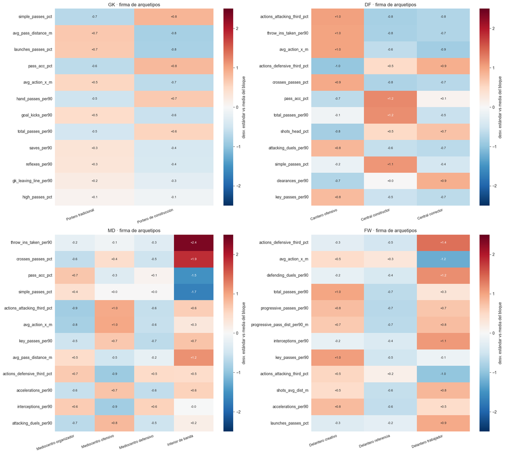

```python
# Mapa de calor de centroides estandarizados (firma de arquetipos)
N_FEAT = 12
fig, axes = plt.subplots(2, 2, figsize=(18, 16))
for ax, b in zip(axes.ravel(), BLOCKS):
    feats = FEATURES_BY_BLOCK[b]
    Xz = pd.DataFrame(X_prep[b], columns=feats); Xz['cluster'] = final_models[b].labels_
    cent = Xz.groupby('cluster')[feats].mean()
    top = cent.std(axis=0).sort_values(ascending=False).head(N_FEAT).index
    M = cent[top].T
    M.columns = [NAMES[(b, c)] for c in M.columns]
    sns.heatmap(M, ax=ax, cmap='RdBu_r', center=0, vmin=-2.5, vmax=2.5,
                annot=True, fmt='+.1f', annot_kws={'size': 8},
                cbar_kws={'label': 'desv. estándar vs media del bloque'})
    ax.set_title(f"{b} · firma de arquetipos", fontsize=12)
    ax.set_xlabel(''); ax.set_ylabel('')
    plt.setp(ax.get_xticklabels(), rotation=20, ha='right', fontsize=9)
plt.tight_layout()
plt.show()
```

### Los doce arquetipos de estilo

**Defensas.** Los tres arquetipos reproducen la taxonomía clásica de la posición. El *carrilero ofensivo* (n=262, 43 %) ocupa posiciones anchas y adelantadas, centra y saca de banda (Gayá, Sakai, Ashley Young). El *central constructor* (n=127, 21 %) destaca por volumen y precisión de pase y progresión desde atrás (Upamecano, Astori, Perrin). El *central corrector* (n=214, 35 %) concentra despejes, juego aéreo y acciones en el tercio defensivo (Giménez, Van der Hoorn, Tomović). Como en porteros, los descriptores de calidad son cercanos a cero y su ligero signo negativo refleja el escaso volumen goleador de la posición, no la finalización: no constituyen un eje de estilo para defensas.

**Centrocampistas.** Es el bloque más rico, con cuatro estilos. El *mediocentro organizador* (n=187, 32 %) juega lejos del área, progresa en largo y genera poco peligro propio (Grillitsch, Campaña, Stephens). El *mediocentro ofensivo* (n=226, 38 %) es el de mayor producción —posición avanzada, pases inteligentes, duelos ofensivos, y los mejores descriptores de calidad del bloque (0,16 goles/90, +0,23 de goles sobre xG)— (Fornals, Thomasson, Brandt). El *mediocentro defensivo* (n=132, 22 %) aporta presencia aérea, físico y faltas (Diamé, Joe Allen, Parolo). Y el *interior de banda* (n=45, 8 %) exhibe la firma más nítida de todo el análisis —saques de banda y centros muy por encima de cualquier otro grupo—, con perfiles de carrilero puro como Jesús Navas o Rubén Peña; agrupar este estilo con el creador, como hacía la partición en tres, habría borrado una identidad futbolística real.

**Delanteros.** Tres arquetipos bien diferenciados. El *delantero creativo* (n=85, 27 %) cae a recibir, asiste y lanza a balón parado, y finaliza muy por encima de lo esperado (0,36 goles/90, +1,44 de goles sobre xG), con Firmino, Martial o Reus como referentes. El *delantero referencia* (n=164, 51 %) es el rematador aéreo, de juego de espaldas, también con sobrerrendimiento sólido (+0,30) (Simeone, Burgstaller, Destro). El *delantero trabajador* (n=71, 22 %) prioriza la presión, los duelos defensivos y las recuperaciones, a costa de la generación de peligro, que es la más baja del bloque (0,16 goles/90, −0,18) (Choupo-Moting, De Préville, Bebou).

### Validación implícita de la decisión

El comportamiento de los descriptores de calidad, que se mantuvieron deliberadamente fuera del espacio de agrupamiento, ofrece una validación indirecta de aquella decisión. En los bloques ofensivos, la calidad de finalización se ordena de forma limpia entre estilos formados sin conocerla: en delanteros, el creativo (+1,44) supera a la referencia (+0,30) y esta al trabajador (−0,18); en centrocampistas, el ofensivo (+0,23) se separa del defensivo (−0,30). El agrupamiento, por tanto, no capturó calidad —como se pretendía—, pero los estilos resultantes resultan ser coherentes en rendimiento, lo que confirma que estilo y calidad son ejes relacionados pero distintos, tal como sostiene la literatura de referencia.

En conjunto, los doce arquetipos presentan una sólida validez aparente: el método recupera, a partir únicamente de volúmenes y precisiones de eventos, una taxonomía que cualquier técnico reconocería, y los jugadores representativos de cada grupo lo confirman. Esta capa interpretable es la cara narrativa del sistema; su contraparte de medición —las coordenadas continuas en el espacio de componentes principales— es la que sustentará el motor de similitud (§9). Antes, la sección siguiente somete los grupos a pruebas de estabilidad y coherencia.

## 7. Validación de los arquetipos

Los doce arquetipos poseen validez aparente, reproducen una taxonomía reconocible y sus jugadores representativos la confirman, pero esa lectura cualitativa requiere un contraste cuantitativo. Esta sección aborda primero la *textura* de la partición definitiva -cómo de asentado está cada jugador en su arquetipo y cómo se distribuyen los doce estilos en el plano-, lo que materializa sobre la segmentación final el carácter continuo diagnosticado en la sección 4, y la somete después a dos pruebas de solidez: su estabilidad ante el remuestreo y su coherencia con un criterio externo a los datos de entrada.

### Silueta por muestra: la textura interna de la partición

El barrido de §4 resumió cada partición en un único coeficiente de silueta medio, pero ese promedio oculta su reparto. El **diagrama de silueta por muestra** lo abre: dibuja el coeficiente de cada jugador, ordenado dentro de su arquetipo, de modo que el perfil de cada banda revela cuántos están bien asentados en su grupo y cuántos quedan en la frontera —silueta cercana a cero o negativa, es decir, casi tan próximos al arquetipo vecino como al propio—. Calculado sobre la partición definitiva de la sección 5 y en el mismo espacio de componentes principales en que se entrenó *K-Means*, es la lectura fina, jugador a jugador, de la frontera difusa que las cuatro vías de la sección 4 detectaron en conjunto (Kaufman & Rousseeuw, 1990).

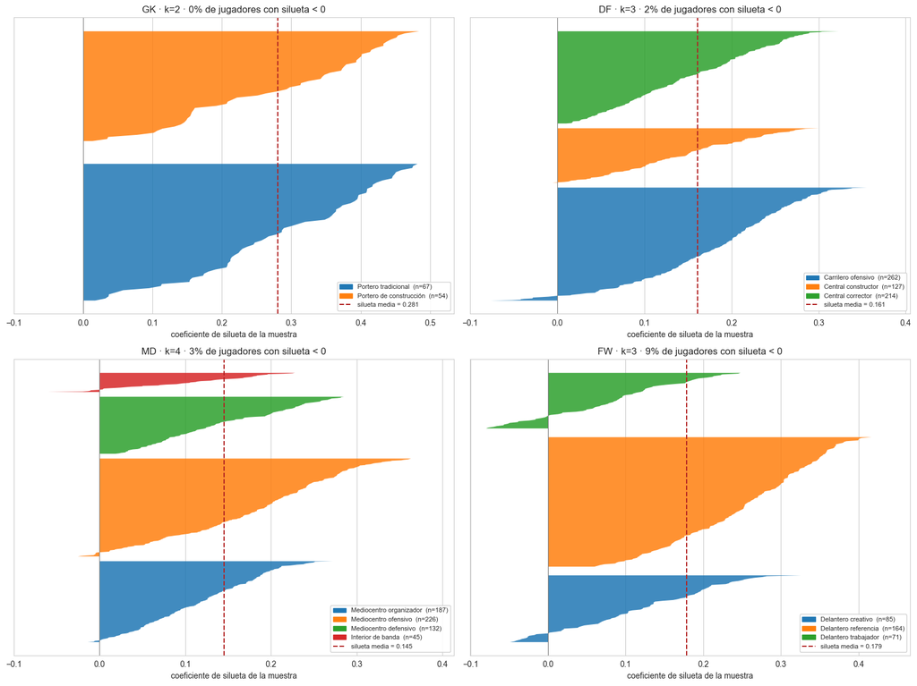

```
Fracción de jugadores en frontera (silueta < 0 = más cerca, de media, del arquetipo vecino):
  GK:  0.0%
  DF:  2.2%
  MD:  3.4%
  FW:  8.8%
```

```python
# Silueta por muestra (knife plot) sobre la partición definitiva
from sklearn.metrics import silhouette_samples, silhouette_score
from matplotlib.patches import Patch
from matplotlib.lines import Line2D
import matplotlib.cm as cm

fig, axes = plt.subplots(2, 2, figsize=(16, 12))
neg_frac = {}

for ax, b in zip(axes.ravel(), BLOCKS):
    X = X_pca[b]
    labels = final_models[b].labels_
    k = K_FINAL[b]
    sv = silhouette_samples(X, labels)              # euclídea: misma entrada que la selección de k en §4
    sil_mean = silhouette_score(X, labels)
    neg_frac[b] = float((sv < 0).mean())

    handles, y_low = [], 0
    for c in range(k):
        cv = np.sort(sv[labels == c])
        color = cm.tab10(c % 10)
        ax.fill_betweenx(np.arange(y_low, y_low + len(cv)), 0, cv,
                         facecolor=color, alpha=0.85, lw=0)
        handles.append(Patch(color=color, label=f"{NAMES[(b, c)]}  (n={len(cv)})"))
        y_low += len(cv) + 10

    handles.append(Line2D([0], [0], color='firebrick', ls='--', lw=1.5,
                          label=f"silueta media = {sil_mean:.3f}"))
    ax.axvline(sil_mean, color='firebrick', ls='--', lw=1.5)
    ax.axvline(0, color='gray', lw=0.8)

    ax.set_title(f"{b} · k={k} · {neg_frac[b]*100:.0f}% de jugadores con silueta < 0", fontsize=12)
    ax.set_xlabel("coeficiente de silueta de la muestra")
    ax.set_yticks([])
    ax.set_xlim(min(-0.10, sv.min() - 0.02), sv.max() + 0.05)
    ax.legend(handles=handles, loc='lower right', fontsize=8, framealpha=0.9)

plt.tight_layout()
plt.show()

print("Fracción de jugadores en frontera (silueta < 0 = más cerca, de media, del arquetipo vecino):")
for b in BLOCKS:
    print(f"  {b}: {neg_frac[b]*100:4.1f}%")
```

### Proyección del espacio de estilo en dos dimensiones (t-SNE)

La silueta cuantifica la frontera difusa, pero no deja verla. Para ello se recurre a una proyección del espacio de componentes principales sobre un plano, que permita representar la nube completa de jugadores y observar cómo se disponen los arquetipos en ella.

La técnica empleada es **t-SNE** (*t-distributed stochastic neighbor embedding*), un método de reducción de dimensión no lineal cuyo objetivo es preservar la **estructura local**: coloca cerca, en el plano, a los jugadores que eran vecinos en el espacio original, aunque para ello distorsione las distancias grandes. Esta propiedad la hace especialmente adecuada para la pregunta de esta sección: si el estilo se organizara en tipos discretos y bien separados, t-SNE los mostraría como islas claramente despegadas; si es un continuo, aparecerá una mancha conexa en la que los arquetipos ocupan regiones contiguas que se funden entre sí. A diferencia del PCA —una proyección lineal que conserva los ejes de máxima varianza—, t-SNE prioriza la fidelidad del vecindario, por lo que sus ejes no tienen interpretación directa y solo importa la disposición relativa de los puntos.

Conviene una cautela metodológica: la separación visual en t-SNE depende de sus parámetros —en particular la *perplexity*, que regula cuántos vecinos considera— y puede exagerar o difuminar grupos, de modo que la proyección se interpreta como confirmación cualitativa de un continuo ya cuantificado por las vías anteriores, y no como prueba autónoma.

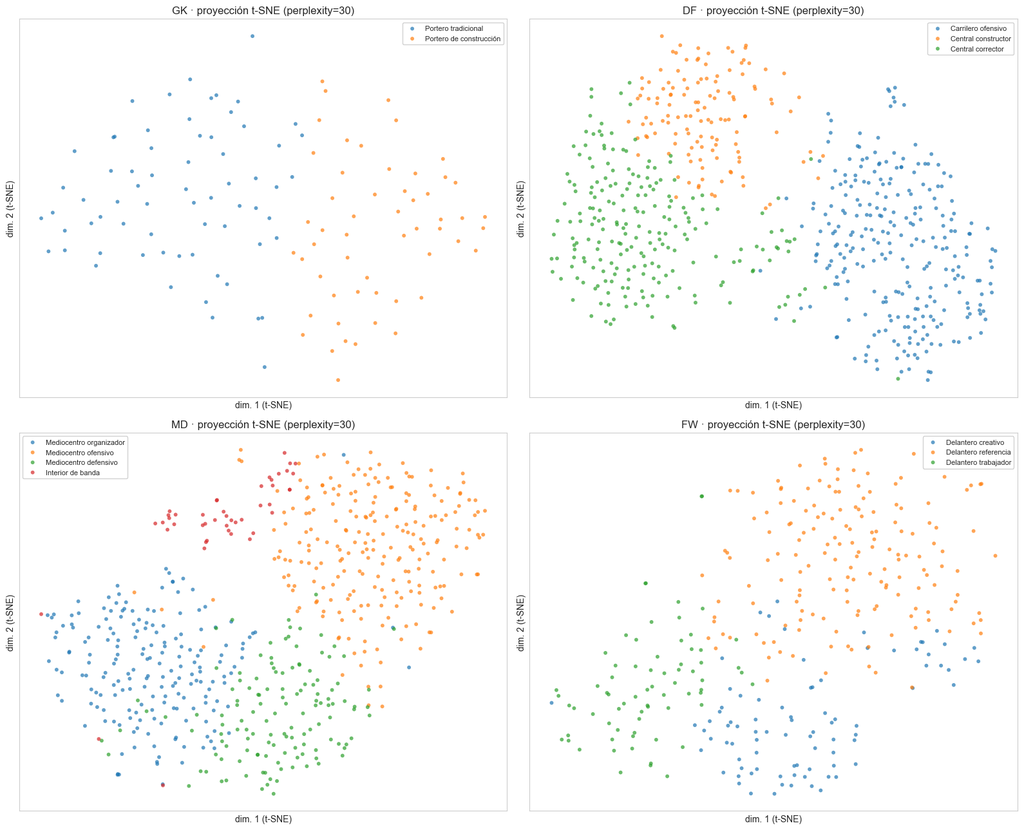

```python
# Proyección 2D del espacio de estilo por bloque (t-SNE) coloreada por arquetipo
from sklearn.manifold import TSNE

fig, axes = plt.subplots(2, 2, figsize=(16, 13))
for ax, b in zip(axes.ravel(), BLOCKS):
    X = X_pca[b]
    labels = final_models[b].labels_
    perp = min(30, (len(X) - 1) // 3)                 # perplexity prudente, acotada al tamaño del bloque
    emb = TSNE(n_components=2, perplexity=perp, init='pca',
               random_state=RANDOM_STATE).fit_transform(X)

    for c in range(K_FINAL[b]):
        m = labels == c
        ax.scatter(emb[m, 0], emb[m, 1], s=18, alpha=0.7,
                   color=cm.tab10(c % 10), label=NAMES[(b, c)], edgecolors='none')
    ax.set_title(f"{b} · proyección t-SNE (perplexity={perp})", fontsize=12)
    ax.set_xticks([]); ax.set_yticks([])
    ax.set_xlabel("dim. 1 (t-SNE)"); ax.set_ylabel("dim. 2 (t-SNE)")
    ax.legend(loc='best', fontsize=8, framealpha=0.9)
plt.tight_layout()
plt.show()
```

### Lectura de la proyección

Las cuatro proyecciones comparten una misma forma: una nube conexa, sin islas despegadas, en la que cada arquetipo ocupa una región contigua que se funde con las vecinas por los bordes. Esa disposición resume las dos mitades del diagnóstico. Por un lado, los colores no se reparten al azar —cada estilo ocupa una zona propia y reconocible—, lo que confirma que los arquetipos son regiones reales del espacio y no un artificio del algoritmo. Por otro, esas zonas se tocan y se solapan en sus límites, sin franjas vacías que las separen, que es la firma del continuo.

La estructura espacial reproduce además la lógica futbolística de cada bloque. En centrocampistas, el organizador y el ofensivo ocupan extremos opuestos del plano y el defensivo se sitúa entre ambos como transición, mientras que el interior de banda forma el grupo más despegado y compacto, coherente con su firma estadística, la más marcada del análisis. En delanteros, el trabajador —de perfil defensivo— se separa con nitidez, en tanto que creativo y referencia comparten una misma región y se funden, en consonancia con que era el bloque de fronteras más difusas. La proyección, por tanto, no solo es compatible con los métodos anteriores: añade que la transición entre estilos es ordenada, no caótica.

Esta es la imagen que da sentido geométrico al hallazgo de toda la sección. El estilo de juego no se distribuye como un conjunto de puntos agrupados en nubes aisladas, sino como una **variedad continua** —una superficie sobre la que los jugadores se reparten sin solución de continuidad— que las variables de estilo recorren de forma gradual. Los doce arquetipos no son, en consecuencia, categorías naturales que el análisis haya descubierto, sino un sistema de coordenadas interpretable con el que nombrar regiones de esa superficie. Es precisamente esta naturaleza continua la que justifica que la herramienta de scouting no se construya sobre la etiqueta de arquetipo, necesariamente gruesa, sino sobre la posición exacta de cada jugador en el espacio, como hace el motor de similitud de la sección 9.

Confirmada visualmente la estructura, las dos pruebas siguientes verifican su solidez.

La primera es la **estabilidad por remuestreo**. Dado que el espacio de estilo es un continuo sin fronteras nítidas, conviene comprobar que la partición no es un artefacto de la muestra concreta de jugadores analizada. Para ello se reentrena el pipeline completo —imputación, escalado, PCA y K-Means— sobre un conjunto de submuestras bootstrap y se compara cada partición resultante con la original mediante el índice de Rand ajustado (ARI), que mide la concordancia entre dos agrupamientos corrigiendo por el azar: vale 1 si coinciden por completo y 0 si la coincidencia es la esperable al azar. Es razonable anticipar valores moderados y no máximos, precisamente porque los jugadores situados en la frontera entre dos estilos cambian de etiqueta con facilidad; lo relevante es que el núcleo de cada arquetipo se mantenga estable a través de las réplicas.

La segunda es la **coherencia con criterios externos**. Se verifica que los arquetipos no reproducen un sesgo de liga —que no agrupan, por ejemplo, a los jugadores de una competición frente a los de otra— cruzándolos con la liga de cada jugador, una variable deliberadamente excluida del agrupamiento. Un reparto equilibrado de cada estilo entre las cinco grandes ligas confirmaría que el método captura estilo de juego y no procedencia.

```python
# Estabilidad de la partición por remuestreo bootstrap (ARI)
from sklearn.metrics import adjusted_rand_score

N_BOOT = 50
rng = np.random.default_rng(RANDOM_STATE)

def pipeline_bloque(b, X_raw):
    pre = build_preprocessor()
    Xp = pre.fit_transform(X_raw)
    pca = PCA(n_components=n_components[b], random_state=RANDOM_STATE).fit(Xp)
    km = KMeans(n_clusters=K_FINAL[b], n_init=10, random_state=RANDOM_STATE).fit(pca.transform(Xp))
    return km.labels_

estabilidad = {}
for b in BLOCKS:
    feats = FEATURES_BY_BLOCK[b]
    base = blocks[b]['cluster'].values
    n = len(blocks[b])
    aris = []
    for _ in range(N_BOOT):
        idx = rng.choice(n, size=n, replace=True)
        lab_boot = pipeline_bloque(b, blocks[b].iloc[idx][feats])
        aris.append(adjusted_rand_score(base[idx], lab_boot))
    estabilidad[b] = np.array(aris)

print("ESTABILIDAD POR BOOTSTRAP — ARI vs partición original")
print(f"{'bloque':<8}{'ARI medio':>11}{'desv.':>9}{'mín':>8}{'máx':>8}")
for b in BLOCKS:
    a = estabilidad[b]
    print(f"{b:<8}{a.mean():>11.3f}{a.std():>9.3f}{a.min():>8.3f}{a.max():>8.3f}")
```

```
ESTABILIDAD POR BOOTSTRAP — ARI vs partición original
bloque    ARI medio    desv.     mín     máx
GK            0.887    0.103   0.562   1.000
DF            0.941    0.048   0.777   1.000
MD            0.784    0.167   0.350   0.967
FW            0.766    0.189   0.324   0.990
```

```python
# Coherencia externa: distribución de arquetipos por liga
clusters_df = clusters_df.merge(
    df[['player_id', 'main_competition_id']], on='player_id', how='left')
clusters_df['liga'] = clusters_df['main_competition_id'].map(BIG5_COMPETITION_IDS)

print("DISTRIBUCIÓN DE ARQUETIPOS POR LIGA (% de fila)\n")
for b in BLOCKS:
    sub = clusters_df[clusters_df['position_group'] == b]
    tab = pd.crosstab(sub['archetype'], sub['liga'], normalize='index') * 100
    print(f"===== {b} =====")
    print(tab.round(0).astype(int).to_string())
    print()
```

```
DISTRIBUCIÓN DE ARQUETIPOS POR LIGA (% de fila)

===== GK =====
liga                     Bundesliga  La Liga  Ligue 1  Premier League  Serie A
archetype
Portero de construcción          26       22       20              11       20
Portero tradicional               9       21       19              31       19

===== DF =====
liga                 Bundesliga  La Liga  Ligue 1  Premier League  Serie A
archetype
Carrilero ofensivo           16       21       24              21       18
Central constructor          20       17       19              17       28
Central corrector            17       25       17              23       18

===== MD =====
liga                     Bundesliga  La Liga  Ligue 1  Premier League  Serie A
archetype
Interior de banda                24       18       11              20       27
Mediocentro defensivo            22       20       16              20       22
Mediocentro ofensivo             19       22       21              23       16
Mediocentro organizador          16       23       23              20       19

===== FW =====
liga                  Bundesliga  La Liga  Ligue 1  Premier League  Serie A
archetype
Delantero creativo            15       20       20              18       27
Delantero referencia          18       21       21              20       20
Delantero trabajador          18       20       23              15       24
```

### Resultados de la validación

**Coherencia externa.** El cruce de cada arquetipo con la liga de procedencia —variable excluida del agrupamiento— confirma que el método captura estilo de juego y no pertenencia a una competición: ningún arquetipo queda monopolizado por una liga, y todos se reparten de forma razonablemente equilibrada entre las cinco. Las desviaciones existentes, lejos de delatar un sesgo, admiten lectura futbolística directa. La más marcada se da en porteros: el portero tradicional, de juego directo, concentra el 31 % de los efectivos en la Premier League y solo el 9 % en la Bundesliga, mientras que el portero de construcción invierte la proporción (26 % frente a 11 %), reflejo del contraste estilístico real entre el juego más directo del fútbol inglés y la cultura de salida de balón del alemán. De forma análoga, el interior de banda y el delantero creativo aparecen ligeramente sobre-representados en la Serie A. Que las únicas asimetrías sean precisamente las que un analista anticiparía refuerza la validez de la segmentación en lugar de amenazarla.

Ambas pruebas, en conjunto, respaldan los doce arquetipos como una segmentación estable y futbolísticamente coherente, apta para sostener el motor de similitud.

## 8. Cierre del bloque de clustering

El recorrido de las secciones anteriores ha transformado una tabla de métricas por noventa minutos en un sistema interpretable de estilos de juego. Partiendo de 1.634 jugadores con minutaje suficiente, se definió para cada bloque posicional un espacio de características centrado en el estilo y depurado de variables degeneradas o ajenas al rol (§1–§2); se redujo su dimensionalidad mediante PCA reteniendo en torno al 80 % de la varianza (§3); y se segmentó cada bloque con K-Means, eligiendo el número de grupos por la interpretabilidad de los arquetipos resultantes ante la ausencia de fronteras nítidas (§4–§5). El resultado son doce arquetipos —dos en porteros, tres en defensas y delanteros, cuatro en centrocampistas— con firma estadística distintiva, descriptores de calidad coherentes y validez aparente confirmada por sus jugadores representativos (§6), que además demostraron ser estables al remuestreo y libres de sesgo de liga (§7).

El hallazgo metodológico que vertebra todo el bloque es que el estilo de juego, dentro de una misma posición, se distribuye sobre un continuo y no en grupos naturalmente aislados. Esta constatación —fundamentada en las métricas internas, en la matriz de disimilaridad y en las limitaciones de K-Means— reorientó el papel del agrupamiento: no como un fin que descubre tipos ocultos, sino como una capa descriptiva que discretiza ese continuo en un vocabulario manejable de estilos. Los doce arquetipos son, en consecuencia, la cara narrativa del sistema: permiten hablar de un jugador como «central de salida» o «delantero creativo» y comunicar perfiles de forma inmediata a un cuerpo técnico.

La capacidad de medición fina, sin embargo, no reside en la etiqueta sino en las coordenadas continuas que cada jugador ocupa en el espacio de componentes principales de su bloque. Forzar a cada futbolista a una única caja discreta sacrifica la información de los perfiles híbridos —el jugador a caballo entre dos estilos—, que son numerosos precisamente por el carácter continuo del espacio. Por ello, la aplicación nuclear del proyecto no se construye sobre las etiquetas de clúster, sino sobre la posición exacta en el espacio de estilo: dos jugadores son tanto más parecidos cuanto más próximos quedan en él. Esa es la idea que materializa el motor de similitud de la sección siguiente, que convierte todo el trabajo de clustering en una herramienta operativa de scouting.

```python
# Persistencia de los artefactos del bloque de clustering
import joblib
from pathlib import Path

ARTIFACTS = Path.cwd().parents[0] / "models" / "clustering"
ARTIFACTS.mkdir(parents=True, exist_ok=True)

for b in BLOCKS:
    joblib.dump({
        'features': FEATURES_BY_BLOCK[b],
        'preprocessor': preprocessors[b],
        'pca': pcas[b],
        'kmeans': final_models[b],
        'k': K_FINAL[b],
        'n_components': n_components[b],
        'X_pca': X_pca[b],
        'ids': ids[b],
    }, ARTIFACTS / f"cluster_{b}.joblib")

clusters_df.to_parquet(ARTIFACTS / "player_clusters.parquet", index=False)

print("ARTEFACTOS GUARDADOS en", ARTIFACTS.relative_to(Path.cwd().parents[0]))
for b in BLOCKS:
    print(f"  cluster_{b}.joblib  ·  {len(FEATURES_BY_BLOCK[b])} feats · "
          f"{n_components[b]} comps · k={K_FINAL[b]} · X_pca {X_pca[b].shape}")
print(f"  player_clusters.parquet  ·  {len(clusters_df)} jugadores × {clusters_df.shape[1]} cols")
```

```
ARTEFACTOS GUARDADOS en models/clustering
  cluster_GK.joblib  ·  13 feats · 5 comps · k=2 · X_pca (121, 5)
  cluster_DF.joblib  ·  51 feats · 17 comps · k=3 · X_pca (603, 17)
  cluster_MD.joblib  ·  51 feats · 17 comps · k=4 · X_pca (590, 17)
  cluster_FW.joblib  ·  51 feats · 17 comps · k=3 · X_pca (320, 17)
  player_clusters.parquet  ·  1634 jugadores × 7 cols
```

## 9. Motor de similitud entre jugadores

El bloque de clustering ha dotado al sistema de un vocabulario de estilos; esta sección lo convierte en la herramienta operativa de scouting del proyecto: un motor que, dado un jugador, recupera los más parecidos a él. Como se argumentó en el cierre anterior, la similitud no se calcula sobre la etiqueta de arquetipo —demasiado gruesa— sino sobre las coordenadas continuas que cada jugador ocupa en el espacio de componentes principales de su bloque. Dos futbolistas son tanto más similares cuanto más alineados están sus perfiles en ese espacio.

La comparación se realiza siempre dentro del mismo bloque posicional: cada bloque tiene su propio espacio de componentes —de dimensión y ejes distintos—, de modo que la distancia entre un portero y un extremo no está siquiera definida. La medida de proximidad elegida es la distancia del coseno, recogida en los materiales de la asignatura, que cuantifica la alineación entre dos vectores con independencia de su magnitud. Sobre las puntuaciones del PCA, cuyo origen coincide con el jugador medio del bloque, el coseno mide hasta qué punto dos jugadores se desvían de ese promedio en la misma dirección estilística. Su tolerancia a la magnitud es deliberada: identifica a jugadores del mismo perfil aunque uno sea una versión más acentuada del otro, dejando la valoración de la intensidad y la calidad a los descriptores reservados. La medida está acotada entre −1 y 1, lo que permite expresarla como un porcentaje de afinidad legible por un cuerpo técnico.

```python
# Índice de similitud por bloque y verificación coseno vs euclídea
from sklearn.metrics.pairwise import cosine_similarity, euclidean_distances

sim_index = {}
for b in BLOCKS:
    meta = ids[b].copy()
    meta['archetype'] = blocks[b]['cluster'].map(lambda c: NAMES[(b, c)]).values
    meta['liga'] = blocks[b]['main_competition_id'].map(BIG5_COMPETITION_IDS).values
    meta = meta.reset_index(drop=True)
    sim_index[b] = {'X': X_pca[b], 'meta': meta,
                    'pos': {n: i for i, n in enumerate(meta['short_name'])}}

def _bloque_de(nombre):
    hit = clusters_df[clusters_df['short_name'] == nombre]
    return hit.iloc[0]['position_group'] if len(hit) else None

def comparar_metricas(nombre, top_n=8):
    b = _bloque_de(nombre)
    X, meta = sim_index[b]['X'], sim_index[b]['meta']
    i = sim_index[b]['pos'][nombre]
    cos = cosine_similarity(X[i:i+1], X)[0]
    euc = -euclidean_distances(X[i:i+1], X)[0]
    rank_cos = meta.iloc[np.argsort(-cos)]['short_name'].drop(index=i, errors='ignore').head(top_n).tolist()
    rank_euc = meta.iloc[np.argsort(-euc)]['short_name'].drop(index=i, errors='ignore').head(top_n).tolist()
    print(f"  {nombre}  ·  bloque {b}  ·  arquetipo: {meta.iloc[i]['archetype']}\n")
    comp = pd.DataFrame({'coseno': rank_cos, 'euclídea': rank_euc})
    print(comp.to_string(index=False))
    solapamiento = len(set(rank_cos) & set(rank_euc))
    print(f"\n  solapamiento top-{top_n}: {solapamiento}/{top_n}")

for nombre in ['D. Upamecano', 'Pablo Fornals', 'Roberto Firmino', 'Jesús Navas']:
    print("="*60)
    comparar_metricas(nombre)
    print()
```

```
============================================================
  D. Upamecano  ·  bloque DF  ·  arquetipo: Central constructor

        coseno        euclídea
       Marcelo     David López
  L. Koscielny Aritz Elustondo
     S. Bender    Rafael Tolói
     G. Cabral       G. Cabral
Diego Llorente       D. Astori
   David López    João Miranda
  G. Chiellini      B. Salamon
        Bartra      S. De Maio

  solapamiento top-8: 2/8

============================================================
  Pablo Fornals  ·  bloque MD  ·  arquetipo: Mediocentro ofensivo

         coseno      euclídea
  H. Mkhitaryan      N. Amiri
        D. Alli R. Nainggolan
           Isco  A. Thomasson
Felipe Anderson H. Mkhitaryan
        W. Zaha     M. Dahoud
      A. Ramsey       F. Tait
       P. Sisto  Carlos Soler
     J. Pastore      Y. Mallı

  solapamiento top-8: 1/8

============================================================
  Roberto Firmino  ·  bloque FW  ·  arquetipo: Delantero creativo

       coseno       euclídea
Son Heung-Min        J. King
   J. Córdoba   Diego Farias
  J. Augustin    A. Schürrle
    F. Kamano    J. Augustin
     M. Depay N. de Préville
      Raffael      L. Muriel
    K. Mbappé        Raffael
 Diego Farias     M. Terrier

  solapamiento top-8: 3/8

============================================================
  Jesús Navas  ·  bloque MD  ·  arquetipo: Interior de banda

     coseno    euclídea
 M. Lazzari     M. Wolf
 D. Lazović  M. Lazzari
    M. Wolf  D. Lazović
M. Phillips M. Phillips
 Rubén Peña  Rubén Peña
   V. Moses    V. Moses
     Rômulo      Rômulo
  M. Heller   E. Thommy

  solapamiento top-8: 7/8
```

### Validación empírica de la métrica

La comparación entre distancia del coseno y euclídea sobre cuatro jugadores de arquetipos distintos resuelve la elección con evidencia. En el caso de un perfil extremo —el interior de banda Jesús Navas, muy alejado del jugador medio— ambas métricas coinciden en siete de los ocho candidatos: cuando un jugador ocupa una posición acentuada del espacio, dirección e intensidad señalan a los mismos vecinos y la métrica es casi indiferente.

La diferencia emerge en los perfiles menos extremos. Para el mediocentro ofensivo Pablo Fornals, la distancia del coseno recupera un conjunto de creadores reconocibles —Mkhitaryan, Dele Alli, Isco, Felipe Anderson—, mientras que la euclídea devuelve un grupo más heterogéneo. El mismo contraste se observa en el central constructor Upamecano —el coseno lo asocia a Koscielny, Chiellini o Bartra— y en el delantero creativo Firmino —vecinos como Son, Depay o Mbappé—. La explicación es la anticipada: al no estar normalizadas las componentes principales, la distancia euclídea queda dominada por la primera componente, la de mayor magnitud, y ordena en gran medida por intensidad sobre el eje principal; la distancia del coseno, en cambio, compara la forma completa del perfil y captura la identidad de estilo. Para un sistema de scouting, cuyo objetivo es proponer jugadores del mismo perfil, la distancia del coseno produce recomendaciones sensiblemente más interpretables y se adopta como medida definitiva. El comportamiento de Navas confirma además la limitación señalada: la elección de métrica solo es relevante para los perfiles que no son extremos, que son precisamente los más numerosos en un espacio continuo.

### Coherencia de la métrica con la taxonomía de estilos

La validación anterior estableció que la distancia del coseno produce recomendaciones interpretables, pero no que esas recomendaciones sean coherentes con la segmentación en arquetipos. Son dos construcciones con metrías distintas: los arquetipos se delimitaron con K-Means, que agrupa por proximidad euclídea a los centroides, mientras que las recomendaciones se ordenan por afinidad del coseno. El contraste entre ambas métricas documentado más arriba es precisamente lo que hace que su acuerdo no esté garantizado: si coseno y euclídea ordenan de forma distinta a los vecinos de un perfil, nada obliga a que la vecindad del coseno caiga dentro del arquetipo trazado por la euclídea.

Ahí está la prueba. Para cada jugador se recupera su vecindad por afinidad del coseno y se mide qué fracción de esos vecinos comparte su arquetipo, a varios tamaños de vecindad. Una coherencia alta demostraría que la métrica de recomendación no traiciona la taxonomía de estilos: el motor no solo propone jugadores que se parecen, sino jugadores del mismo perfil reconocido por el agrupamiento. Como una proporción solo es interpretable frente a una referencia, se compara con la coherencia que produciría una vecindad escogida al azar dentro del bloque.

```python
def coherencia_arquetipo(b, ks=(1, 3, 5, 10)):
    X = sim_index[b]['X']
    arq = sim_index[b]['meta']['archetype'].to_numpy()
    n = len(arq)
    S = cosine_similarity(X)
    np.fill_diagonal(S, -np.inf)                 # excluir el propio jugador
    orden = np.argsort(-S, axis=1)               # vecinos por afinidad descendente
    out = {k: (arq[orden[:, :k]] == arq[:, None]).mean() for k in ks}
    _, counts = np.unique(arq, return_counts=True)
    azar = (counts * (counts - 1)).sum() / (n * (n - 1))   # vecino aleatorio del bloque
    return out, azar

ks = (1, 3, 5, 10)
filas = []
for b in BLOCKS:
    out, azar = coherencia_arquetipo(b, ks)
    filas.append({'bloque': b, **{f'top{k}': out[k] for k in ks}, 'azar': azar})

coh = pd.DataFrame(filas).set_index('bloque')
print((coh * 100).round(1).to_string())
```

```
         top1   top3   top5  top10   azar
bloque
GK     96.700 95.000 93.900 91.700 50.200
DF     93.200 92.400 92.100 91.200 35.800
MD     89.500 89.000 88.100 86.700 30.200
FW     90.300 86.700 86.800 85.800 38.100
```

La coherencia supera ampliamente al azar en los cuatro bloques y a todos los tamaños de vecindad: aun considerando los diez vecinos más afines, más de ocho de cada diez comparten el arquetipo del jugador consultado, frente a niveles de coincidencia aleatoria que oscilan entre el 30% y el 50%. Puesto que la recomendación se ordena por coseno y los arquetipos se trazaron con la proximidad euclídea de K-Means —dos metrías que la sección anterior mostró divergentes—, este acuerdo no estaba garantizado de antemano: confirma que la vecindad del coseno cae dentro de la partición de estilos y que, por tanto, la métrica adoptada para el motor no contradice la segmentación que la sustenta. El margen sobre el azar es además mayor donde la partición es más fina, pues la coincidencia fortuita decrece al aumentar el número de arquetipos del bloque.

Más allá de superar el umbral, la coherencia decrece de forma ordenada de porteros a delanteros en cuanto se considera la vecindad y no solo el vecino más próximo: los bloques compactos concentran a sus semejantes dentro del arquetipo casi sin fuga, mientras que en los más difusos una fracción creciente de vecinos pertenece ya a perfiles colindantes. Es el mismo gradiente que arrojaron la disimilaridad media, la proporción de jugadores en frontera y la disposición del t-SNE, y reaparece aquí desde una medida por completo distinta. Que cuatro técnicas independientes dibujen el mismo orden refuerza la tesis que vertebra el bloque: los estilos no forman tipos aislados sino un espectro continuo, más nítido en unas posiciones que en otras.

Para el motor, la lectura es directa. Sus recomendaciones no son solo plausibles a la vista, sino vecinos del mismo perfil reconocido por un agrupamiento ajeno a la métrica de consulta. La fuga hacia arquetipos colindantes en los bloques difusos no es un fallo, sino el reflejo fiel de un espacio donde los perfiles se solapan: en esas zonas el propio concepto de arquetipo es más poroso, y el motor lo hereda. Queda así validado como herramienta coherente con la capa descriptiva del sistema, y no como un cálculo de afinidad desconectado de ella.

### Incorporación del valor de mercado al motor

Las recomendaciones de estilo, por sí solas, ignoran una restricción decisiva en el scouting real: el presupuesto. Un motor que propone perfiles afines sin noción de coste sugeriría con igual naturalidad a un futbolista de élite y a uno asequible para cubrir la misma necesidad, una recomendación inservible para un club modesto. Para cerrar esta brecha se incorpora el valor de mercado obtenido en el notebook 04b —la valoración de Transfermarkt contemporánea a la temporada 2017/18, enlazada al universo de jugadores por su identificador—, que se carga aquí como descriptor adicional.

Coherente con el principio que vertebra todo el sistema, el valor de mercado no altera el cálculo de afinidad: la similitud se sigue midiendo exclusivamente sobre el estilo, en el espacio de componentes principales. El precio interviene únicamente como filtro posterior sobre las recomendaciones ya ordenadas por estilo, igual que la edad o la liga. De este modo, la afinidad responde a la pregunta «¿quién juega como este futbolista?» y los filtros acotan la respuesta a «¿cuáles de ellos puede permitirse y necesita el club?». Los jugadores sin valoración disponible se conservan en los resultados, pero quedan excluidos al aplicar un filtro de precio, pues recomendar como asequible a quien no tiene coste conocido sería injustificado.

```python
# Incorporación del valor de mercado
try:
    market_values = pd.read_sql(
        "SELECT player_id, market_value_eur FROM gold.player_market_values", engine)
    print(f"Valores de mercado cargados: {len(market_values)} jugadores")
    print(f"Cobertura sobre el universo de clustering: "
          f"{clusters_df['player_id'].isin(market_values['player_id']).mean()*100:.1f}%")
except Exception:
    market_values = pd.DataFrame(columns=['player_id', 'market_value_eur'])
    print("⚠ gold.player_market_values no encontrada — ejecuta nb04b primero. "
          "Los filtros de precio quedarán inactivos (valor = s/d).")
```

```
Valores de mercado cargados: 2334 jugadores
Cobertura sobre el universo de clustering: 92.6%
```

```python
# Función de consulta de jugadores similares
DESC_COLS = ['age_at_season', 'goals_per90', 'goals_minus_xg']

def jugadores_similares(nombre, top_n=10):
    b = _bloque_de(nombre)
    if b is None:
        cand = clusters_df[clusters_df['short_name'].str.contains(nombre, case=False, na=False)]
        msg = "sin coincidencias" if cand.empty else "¿quizás? " + ", ".join(cand['short_name'].head(8))
        print(f"'{nombre}' no encontrado. {msg}")
        return None

    X, meta = sim_index[b]['X'], sim_index[b]['meta']
    i = sim_index[b]['pos'][nombre]
    cos = cosine_similarity(X[i:i+1], X)[0]

    res = meta.copy()
    res['afinidad'] = (cos * 100).round(1)
    res = res[res.index != i].sort_values('afinidad', ascending=False).head(top_n)
    res = res.merge(df[['player_id'] + DESC_COLS], on='player_id', how='left')
    res = res.merge(market_values, on='player_id', how='left')

    obj = df[df['player_id'] == meta.iloc[i]['player_id']].iloc[0]
    obj_mv = market_values.loc[market_values['player_id'] == meta.iloc[i]['player_id'], 'market_value_eur']
    obj_mv = f"{obj_mv.iloc[0]/1e6:.1f}M€" if len(obj_mv) else "s/d"
    print(f"🎯 {nombre} · {b} · {meta.iloc[i]['archetype']} · {meta.iloc[i]['liga']} · {obj_mv}")
    print(f"   {obj['age_at_season']:.0f} años · {obj['goals_per90']:.2f} g/90 · G−xG {obj['goals_minus_xg']:+.2f}\n")

    out = res[['short_name', 'afinidad', 'archetype', 'liga'] + DESC_COLS + ['market_value_eur']].rename(
        columns={'short_name': 'jugador', 'age_at_season': 'edad',
                 'goals_per90': 'g/90', 'goals_minus_xg': 'G−xG', 'market_value_eur': 'valor'})
    out['edad'] = out['edad'].round(0).astype('Int64')
    out['valor_M€'] = (out.pop('valor') / 1e6).round(1)
    return out.reset_index(drop=True)
```

### Casos de uso: del motor a la decisión de scouting

Un motor de similitud cobra valor cuando responde a preguntas reales de un departamento deportivo. Se ilustran dos escenarios canónicos del scouting basado en datos, que combinan la afinidad de estilo con filtros sobre los atributos reservados —edad, liga y el valor de mercado incorporado en el notebook 04b—.

El primero es la **sustitución de una baja**: ante la venta o lesión de un jugador, encontrar perfiles de estilo equivalente que el club pueda permitirse. A la consulta de similitud se le añaden los filtros que impondría una dirección deportiva —una horquilla de edad y, sobre todo, un techo de presupuesto— para acotar la lista a candidatos realmente viables.

El segundo es la **detección de oportunidades de mercado**, la lógica que han popularizado clubes como Brentford o Brighton: localizar jugadores del mismo perfil que una referencia consolidada pero en contextos de menor coste —jóvenes, en otras ligas, por debajo de un valor de mercado— y, preferiblemente, con indicios de rendimiento al alza. La combinación de afinidad de estilo, valor de mercado contemporáneo y sobrerrendimiento respecto al xG materializa esta estrategia de identificación temprana de talento infravalorado.

```python
# Caso 1: sustituir una baja
def sustituir_baja(nombre, top_n=8, edad_max=None, valor_max=None, ligas=None):
    res = jugadores_similares(nombre, top_n=300)
    if res is None:
        return None
    if edad_max is not None:  res = res[res['edad'] <= edad_max]
    if valor_max is not None: res = res[res['valor_M€'] <= valor_max]   # en M€
    if ligas is not None:     res = res[res['liga'].isin(ligas)]
    return res.head(top_n).reset_index(drop=True)

# Escenario: el club pierde a Isco y busca un relevo de su perfil, menor de 26 años, pero un presupuesto de 20 millones
sustituir_baja('Isco', top_n=8, edad_max=26, valor_max= 20.0)
```

```
🎯 Isco · MD · Mediocentro ofensivo · La Liga · 75.0M€
   25 años · 0.30 g/90 · G−xG +1.68
```

|  | jugador | afinidad | archetype | liga | edad | g/90 | G−xG | valor_M€ |
| --- | --- | --- | --- | --- | --- | --- | --- | --- |
| 0 | A. Iwobi | 81.700 | Mediocentro ofensivo | Premier League | 21 | 0.147 | -0.470 | 10.000 |
| 1 | Pablo Fornals | 80.100 | Mediocentro ofensivo | La Liga | 22 | 0.103 | 0.177 | 15.000 |
| 2 | F. Tait | 80.000 | Mediocentro ofensivo | Ligue 1 | 25 | 0.160 | 0.052 | 5.000 |
| 3 | Thiago Mendes | 73.400 | Mediocentro ofensivo | Ligue 1 | 26 | 0.116 | -0.154 | 5.500 |
| 4 | S. Gnabry | 70.900 | Mediocentro ofensivo | Bundesliga | 22 | 0.594 | 4.959 | 20.000 |
| 5 | A. Januzaj | 70.500 | Mediocentro ofensivo | La Liga | 23 | 0.171 | -2.485 | 10.000 |
| 6 | R. Saponara | 70.100 | Mediocentro ofensivo | Serie A | 26 | 0.000 | -1.631 | 9.000 |
| 7 | P. Zieliński | 69.800 | Mediocentro ofensivo | Serie A | 23 | 0.216 | 1.585 | 20.000 |

```python
# Caso 2: oportunidad de mercado
def oportunidad_mercado(nombre, top_n=8, edad_max=24, valor_max=None,
                        afinidad_min=70, sobrerend_min=0.0):
    res = jugadores_similares(nombre, top_n=300)
    if res is None:
        return None
    obj_liga = clusters_df.loc[clusters_df['short_name'] == nombre, 'liga'].iloc[0]
    f = ((res['edad'] <= edad_max) & (res['afinidad'] >= afinidad_min) &
         (res['G−xG'] >= sobrerend_min) & (res['liga'] != obj_liga))
    if valor_max is not None: f &= (res['valor_M€'] <= valor_max)
    return res[f].head(top_n).reset_index(drop=True)

# Escenario: perfil tipo Mkhitaryan, joven (≤24), fuera de su liga, rindiendo por encima de su xG y hasta 60 millones de valor de mercado
oportunidad_mercado('H. Mkhitaryan', top_n=8, edad_max=24, valor_max=60.0)
```

```
🎯 H. Mkhitaryan · MD · Mediocentro ofensivo · Premier League · 35.0M€
   29 años · 0.16 g/90 · G−xG +0.44
```

|  | jugador | afinidad | archetype | liga | edad | g/90 | G−xG | valor_M€ |
| --- | --- | --- | --- | --- | --- | --- | --- | --- |
| 0 | Felipe Anderson | 87.900 | Mediocentro ofensivo | Serie A | 24 | 0.312 | 1.579 | 30.000 |
| 1 | Pablo Fornals | 84.200 | Mediocentro ofensivo | La Liga | 22 | 0.103 | 0.177 | 15.000 |
| 2 | Marco Asensio | 79.100 | Mediocentro ofensivo | La Liga | 22 | 0.245 | 0.442 | 50.000 |
| 3 | J. Brandt | 78.400 | Mediocentro ofensivo | Bundesliga | 21 | 0.347 | 4.157 | 40.000 |
| 4 | L. Bittencourt | 77.500 | Mediocentro ofensivo | Bundesliga | 24 | 0.279 | 1.661 | 6.000 |
| 5 | S. Gnabry | 76.700 | Mediocentro ofensivo | Bundesliga | 22 | 0.594 | 4.959 | 20.000 |
| 6 | A. Thomasson | 76.200 | Mediocentro ofensivo | Ligue 1 | 24 | 0.174 | 0.258 | 8.000 |
| 7 | Mikel Oyarzabal | 76.000 | Mediocentro ofensivo | La Liga | 20 | 0.388 | 5.072 | 35.000 |

### Lectura de los casos

Los dos escenarios ilustran el funcionamiento del sistema sobre consultas reales, ya acotadas por presupuesto. En el caso de sustitución, partiendo de Isco —valorado en 75 M€— y buscando un relevo de su perfil de hasta 26 años y un máximo de 20 M€, el motor descarta a los candidatos más afines pero inalcanzables, como Kevin De Bruyne, y propone alternativas asequibles del mismo arquetipo: Alex Iwobi, Pablo Fornals o Thiago Mendes, todos por debajo del techo de coste fijado. La herramienta traduce así la afinidad de estilo en una lista de fichajes realistas para un club con recursos limitados, que es precisamente el problema que un motor sin noción de precio no podía resolver.

El caso de detección de oportunidades de mercado expone el mayor valor del sistema. Tomando a un Mkhitaryan consolidado como referencia y filtrando candidatos jóvenes —hasta 24 años—, fuera de su liga, por debajo de 60 M€ y con rendimiento por encima de su xG, el motor señala a Serge Gnabry, Julian Brandt o Mikel Oyarzabal: perfiles estilísticamente afines, en una fase temprana de su carrera y con producción ofensiva notable en la temporada analizada. Es exactamente la lógica de identificación de talento infravalorado que clubes como Brentford o Brighton han convertido en ventaja competitiva.

Conviene subrayar el papel del sistema y sus límites. La afinidad mide estilo; los descriptores de rendimiento y el valor de mercado aportan contexto, pero un sobrerrendimiento muy elevado respecto al xG —como el que presentan algunos de estos candidatos— es a la vez una señal de oportunidad y una advertencia, pues las finalizaciones insostenibles tienden a regresar a la media, según se argumentó al reservar estas variables fuera del agrupamiento. El motor, por tanto, prioriza candidatos a investigar y no emite veredictos: ordena el espacio de búsqueda por estilo, lo acota por criterios objetivos y deja la valoración final al criterio humano. Esta división de roles —la máquina propone perfiles, el analista decide— es la que hace del sistema una herramienta de scouting utilizable y no una caja negra.

### Ficha comparativa de scouting

Las tablas anteriores ordenan y filtran candidatos, pero un cuerpo técnico lee perfiles de un vistazo, no columnas de números. El formato consolidado para ello es el gráfico de percentiles por posición —el radar de scouting que popularizó StatsBomb—, que sitúa cada métrica del jugador como un percentil dentro de su grupo posicional: el percentil traduce un valor crudo, ilegible en aislamiento, a una posición relativa («supera al 80 % de los centrocampistas en pases progresivos»), la única lectura con sentido comparativo.

Aquí se adapta ese formato a una comparación directa entre el jugador objetivo y su recomendación más afín, superponiendo ambos perfiles sobre los mismos ejes. La afinidad del coseno cuantifica el parecido en un número; esta figura lo hace visible: dos perfiles que se solapan casi por completo son la traducción gráfica de una afinidad alta. Las métricas se agrupan por fase del juego —construcción, finalización, defensa— y los percentiles se calculan dentro del bloque y solo sobre jugadores con minutos suficientes, de modo que la comparación es siempre frente a pares reales de la misma posición.

Conviene una precisión de lectura: el percentil mide cuánto presenta un jugador de cada rasgo respecto a sus pares, no cuán bueno es. Un percentil alto en pases en largo describe un estilo, no una virtud. La figura es, por tanto, coherente con el principio del sistema: describe el perfil, mientras que el valor de mercado y el rendimiento ya tabulados aportan el juicio de calidad que la similitud reserva fuera.

```python
from scipy.stats import percentileofscore

# Plantilla de la ficha por bloque: fases ordenadas → features (grounded en StatsBomb/FBref)
PIZZA = {
    'GK': {'Distribución': ['pass_acc_pct', 'simple_passes_pct', 'launches_passes_pct',
                            'avg_pass_distance_m', 'high_passes_pct', 'total_passes_per90',
                            'hand_passes_per90', 'goal_kicks_per90'],
           'Parada': ['saves_per90', 'reflexes_per90'],
           'Salida': ['gk_leaving_line_per90', 'avg_action_x_m']},
    'DF': {'Construcción': ['pass_acc_pct', 'progressive_passes_per90', 'avg_pass_distance_m',
                            'crosses_passes_pct', 'key_passes_per90'],
           'Defensa': ['defending_duels_won_pct', 'interceptions_per90', 'clearances_per90',
                       'sliding_tackles_per90', 'air_duels_won_pct'],
           'Posición': ['avg_action_x_m']},
    'MD': {'Creación': ['total_passes_per90', 'pass_acc_pct', 'progressive_passes_per90',
                        'key_passes_per90', 'smart_passes_pct'],
           'Finalización': ['xg_per90', 'shots_on_target_per90'],
           'Defensa': ['defending_duels_won_pct', 'interceptions_per90', 'air_duels_won_pct'],
           'Conducción': ['accelerations_per90']},
    'FW': {'Finalización': ['xg_per90', 'shots_per90', 'shots_on_target_per90', 'xg_per_shot'],
           'Creación': ['key_passes_per90', 'assists_per90'],
           'Progresión': ['progressive_passes_per90', 'accelerations_per90'],
           'Juego aéreo': ['air_duels_won_pct', 'head_passes_pct'],
           'Posición': ['avg_action_x_m']},
}

LABELS = {
    'pass_acc_pct': '% acierto\npase', 'simple_passes_pct': '% pase\nsencillo',
    'launches_passes_pct': '% pase\nen largo', 'avg_pass_distance_m': 'Dist. media\npase (m)',
    'high_passes_pct': '% pase\naéreo', 'total_passes_per90': 'Pases/90',
    'hand_passes_per90': 'Saques\nde mano/90', 'goal_kicks_per90': 'Saques de\npuerta/90',
    'saves_per90': 'Paradas/90', 'reflexes_per90': 'Reflejos/90',
    'gk_leaving_line_per90': 'Salidas/90', 'avg_action_x_m': 'Pos. media\nen campo (m)',
    'progressive_passes_per90': 'Pases\nprogr./90', 'crosses_passes_pct': '% centros',
    'key_passes_per90': 'Pases\nclave/90', 'defending_duels_won_pct': '% duelos\ndef. ganados',
    'interceptions_per90': 'Intercep./90', 'clearances_per90': 'Despejes/90',
    'sliding_tackles_per90': 'Entradas/90', 'air_duels_won_pct': '% duelos\naéreos gan.',
    'smart_passes_pct': '% pases\nentre líneas', 'xg_per90': 'xG/90',
    'shots_on_target_per90': 'Tiros a\npuerta/90', 'accelerations_per90': 'Conducc.\nrápidas/90',
    'shots_per90': 'Tiros/90', 'xg_per_shot': 'xG\npor tiro', 'assists_per90': 'Asist./90',
    'head_passes_pct': '% pase\nde cabeza',
}

def percentiles_bloque(b, player_id):
    feats = [f for grp in PIZZA[b].values() for f in grp]
    pool = df[(df['position_group'] == b) & (df['meets_450min'])]
    fila = df[df['player_id'] == player_id].iloc[0]
    pct = [round(percentileofscore(pool[f].dropna(), fila[f], kind='mean')) for f in feats]
    raw = [fila[f] for f in feats]
    return feats, pct, raw

# Comprobación: Mkhitaryan (MD), debe puntuar alto en creación
pid = clusters_df.loc[clusters_df['short_name'] == 'H. Mkhitaryan', 'player_id'].iloc[0]
feats, pct, raw = percentiles_bloque('MD', pid)
print(pd.DataFrame({'feature': feats, 'valor': np.round(raw, 2), 'percentil': pct}).to_string(index=False))
```

```
                 feature  valor  percentil
      total_passes_per90 50.450         72
            pass_acc_pct  0.810         40
progressive_passes_per90 10.020         40
        key_passes_per90  0.420         77
        smart_passes_pct  0.050         92
                xg_per90  0.130         73
   shots_on_target_per90  0.730         87
 defending_duels_won_pct  0.420         22
     interceptions_per90  3.340         34
       air_duels_won_pct  0.400         26
     accelerations_per90  1.670         87
```

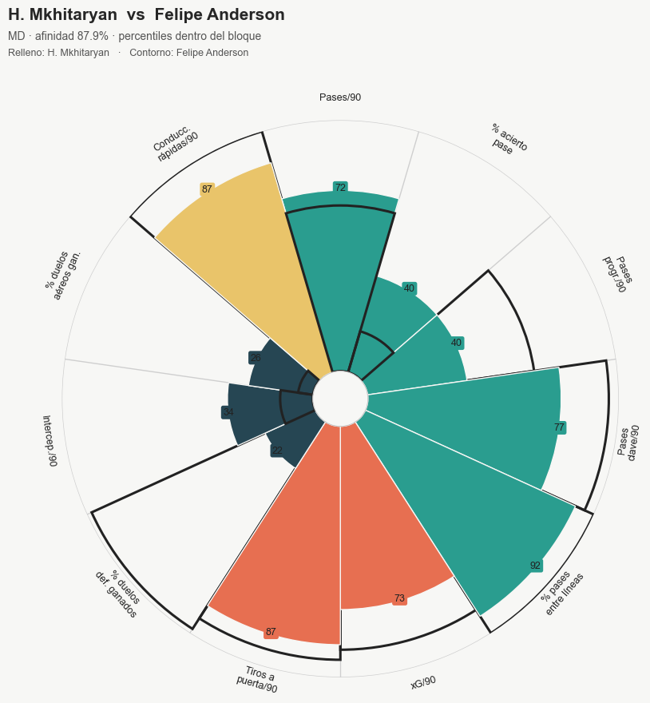

```python
from mplsoccer import PyPizza

FASE_COLOR = {'Construcción': '#2a9d8f', 'Creación': '#2a9d8f', 'Distribución': '#2a9d8f',
              'Finalización': '#e76f51', 'Defensa': '#264653', 'Parada': '#264653',
              'Posición': '#8d99ae', 'Salida': '#8d99ae', 'Conducción': '#e9c46a',
              'Progresión': '#e9c46a', 'Juego aéreo': '#f4a261'}

def ficha_comparativa(objetivo, similar, b=None):
    b = b or _bloque_de(objetivo)
    feats = [f for grp in PIZZA[b].values() for f in grp]
    slice_colors = [FASE_COLOR[fase] for fase, grp in PIZZA[b].items() for _ in grp]
    params = [LABELS[f] for f in feats]

    pid_o = clusters_df.loc[clusters_df['short_name'] == objetivo, 'player_id'].iloc[0]
    pid_s = clusters_df.loc[clusters_df['short_name'] == similar, 'player_id'].iloc[0]
    _, pct_o, _ = percentiles_bloque(b, pid_o)
    _, pct_s, _ = percentiles_bloque(b, pid_s)

    i = sim_index[b]['pos'][objetivo]
    afin = round(cosine_similarity(sim_index[b]['X'][i:i+1],
                 sim_index[b]['X'][sim_index[b]['pos'][similar]:sim_index[b]['pos'][similar]+1])[0][0] * 100, 1)

    baker = PyPizza(params=params, background_color='#f7f7f5',
                    straight_line_color='#cfcfcf', straight_line_lw=1,
                    last_circle_lw=1, last_circle_color='#cfcfcf',
                    other_circle_lw=0, inner_circle_size=11)
    fig, ax = baker.make_pizza(
        pct_o, compare_values=pct_s, figsize=(9, 10),
        slice_colors=slice_colors, value_colors=['#222']*len(params),
        value_bck_colors=slice_colors,
        kwargs_slices=dict(edgecolor='#f7f7f5', zorder=2, linewidth=1),
        kwargs_compare=dict(facecolor='none', edgecolor='#222', linewidth=2.2, zorder=3),
        kwargs_params=dict(color='#222', fontsize=9),
        kwargs_values=dict(color='#fff', fontsize=9, zorder=3,
                           bbox=dict(edgecolor='none', boxstyle='round,pad=0.2')),
        kwargs_compare_values=dict(color='#222', fontsize=9, alpha=0))
    fig.text(0.05, 0.97, f"{objetivo}  vs  {similar}", size=15, weight='bold')
    fig.text(0.05, 0.945, f"{b} · afinidad {afin}% · percentiles dentro del bloque", size=10, color='#555')
    fig.text(0.05, 0.925, f"Relleno: {objetivo}   ·   Contorno: {similar}", size=9, color='#555')
    plt.show()
    return fig

ficha_comparativa('H. Mkhitaryan', 'Felipe Anderson');
```

```python
def pares_mas_afines(b, top=10):
    X = sim_index[b]['X']
    meta = sim_index[b]['meta'].reset_index(drop=True)
    regs = set(df.loc[df['meets_900min'], 'player_id'])
    mask = meta['player_id'].isin(regs).to_numpy()
    S = cosine_similarity(X)
    np.fill_diagonal(S, -np.inf)
    S[~mask, :] = -np.inf
    S[:, ~mask] = -np.inf
    iu = np.triu_indices_from(S, k=1)
    aff = S[iu]
    order = np.argsort(-aff)[:top]
    rows = [(meta.iloc[iu[0][k]]['short_name'], meta.iloc[iu[1][k]]['short_name'],
             meta.iloc[iu[0][k]]['archetype'], round(aff[k]*100, 1)) for k in order]
    return pd.DataFrame(rows, columns=['jugador A', 'jugador B', 'arquetipo', 'afinidad'])

for b in ['FW', 'MD', 'DF']:
    print(f"\n===== {b} · pares más afines (titulares, ≥900 min) =====")
    print(pares_mas_afines(b).to_string(index=False))
```

```
===== FW · pares más afines (titulares, ≥900 min) =====
        jugador A         jugador B            arquetipo  afinidad
        J. Iličić        F. Thauvin   Delantero creativo    92.400
      V. Ibišević         L. Alario Delantero referencia    91.000
     Suk Hyun-Jun         A. Barnes Delantero referencia    90.700
       D. Perotti       A. Schürrle   Delantero creativo    90.300
         L. Messi         J. Iličić   Delantero creativo    89.700
       I. Santini       G. Lapadula Delantero referencia    89.500
       C. Benteke          D. Selke Delantero referencia    89.000
         M. Depay Philippe Coutinho   Delantero creativo    89.000
Cristiano Ronaldo         S. Agüero   Delantero creativo    88.800
         S. Vokes       N. Füllkrug Delantero referencia    88.200

===== MD · pares más afines (titulares, ≥900 min) =====
    jugador A         jugador B               arquetipo  afinidad
   N. Redmond           D. Gray    Mediocentro ofensivo    93.600
 K. Bellarabi         F. Chiesa    Mediocentro ofensivo    93.300
   Javi Fuego        C. Sánchez   Mediocentro defensivo    93.100
     F. Kainz José Luis Morales    Mediocentro ofensivo    92.900
    Iturraspe     F. Magnanelli Mediocentro organizador    92.000
   A. Januzaj         F. Chiesa    Mediocentro ofensivo    91.600
  Rubén Pérez     F. Magnanelli Mediocentro organizador    91.400
F. Magnanelli         E. Pulgar Mediocentro organizador    91.200
        Timor         M. Büchel Mediocentro organizador    91.100
R. Amalfitano           L. Cook Mediocentro organizador    91.000

===== DF · pares más afines (titulares, ≥900 min) =====
    jugador A      jugador B          arquetipo  afinidad
 R. Shawcross        K. Long  Central corrector    94.600
   C. Biraghi         P. Max Carrilero ofensivo    93.200
   A. Masuaku      J. Mojica Carrilero ofensivo    92.700
   C. Biraghi     J. Holebas Carrilero ofensivo    92.600
     T. Smith       D. Opare Carrilero ofensivo    92.400
    José Gayá     A. Masuaku Carrilero ofensivo    92.400
   R. Aguilar     K. Malcuit Carrilero ofensivo    91.800
    K. Rausch     J. Holebas Carrilero ofensivo    91.700
Marcos Alonso M. Halstenberg Carrilero ofensivo    91.700
   Lucas Lima     J. Holebas Carrilero ofensivo    91.500
```

```python
def _pizza_ax(ax, objetivo, similar, b):
    feats = [f for grp in PIZZA[b].values() for f in grp]
    colors = [FASE_COLOR[fase] for fase, grp in PIZZA[b].items() for _ in grp]
    params = [LABELS[f] for f in feats]
    pid_o = clusters_df.loc[clusters_df['short_name'] == objetivo, 'player_id'].iloc[0]
    pid_s = clusters_df.loc[clusters_df['short_name'] == similar, 'player_id'].iloc[0]
    _, pct_o, _ = percentiles_bloque(b, pid_o)
    _, pct_s, _ = percentiles_bloque(b, pid_s)
    io, isim = sim_index[b]['pos'][objetivo], sim_index[b]['pos'][similar]
    afin = round(cosine_similarity(sim_index[b]['X'][io:io+1], sim_index[b]['X'][isim:isim+1])[0][0] * 100, 1)
    baker = PyPizza(params=params, background_color='#f7f7f5',
                    straight_line_color='#cfcfcf', straight_line_lw=1,
                    last_circle_lw=1, last_circle_color='#cfcfcf',
                    other_circle_lw=0, inner_circle_size=9)
    baker.make_pizza(pct_o, compare_values=pct_s, ax=ax,
                     slice_colors=colors, value_bck_colors=colors,
                     kwargs_slices=dict(edgecolor='#f7f7f5', zorder=2, linewidth=1),
                     kwargs_compare=dict(facecolor='none', edgecolor='#222', linewidth=2.2, zorder=3),
                     kwargs_params=dict(color='#222', fontsize=8),
                     kwargs_values=dict(color='#fff', fontsize=8, zorder=3,
                                        bbox=dict(edgecolor='none', boxstyle='round,pad=0.2')),
                     kwargs_compare_values=dict(alpha=0))
    return afin

def panel_fichas(objetivo, gemelo, contraste, b=None):
    b = b or _bloque_de(objetivo)
    fig, axs = plt.subplots(1, 2, figsize=(17, 9.5), subplot_kw=dict(projection='polar'))
    fig.patch.set_facecolor('#f7f7f5')
    a1 = _pizza_ax(axs[0], objetivo, gemelo, b)
    a2 = _pizza_ax(axs[1], objetivo, contraste, b)
    fig.text(0.5, 0.97, f"{objetivo} · {b} · perfil de estilo en percentiles del bloque",
             size=15, weight='bold', ha='center')
    fig.text(0.27, 0.92, f"vs {gemelo} · afinidad {a1}%", size=12, ha='center', color='#2a9d8f', weight='bold')
    fig.text(0.73, 0.92, f"vs {contraste} · afinidad {a2}%", size=12, ha='center', color='#e76f51', weight='bold')
    fig.text(0.5, 0.05, "Relleno: jugador objetivo · Contorno: comparado", size=10, ha='center', color='#555')
    plt.show()
    return fig
```

```
  short_name            archetype    afin
 L. Depoitre Delantero referencia -76.000
Borja Bastón Delantero referencia -72.800
    M. Gómez Delantero referencia -69.600
    D. Selke Delantero referencia -66.800
   M. Destro Delantero referencia -66.200
  C. Beauvue Delantero referencia -66.100
 F. Di Santo Delantero referencia -65.000
 A. Paloschi Delantero referencia -63.400
```

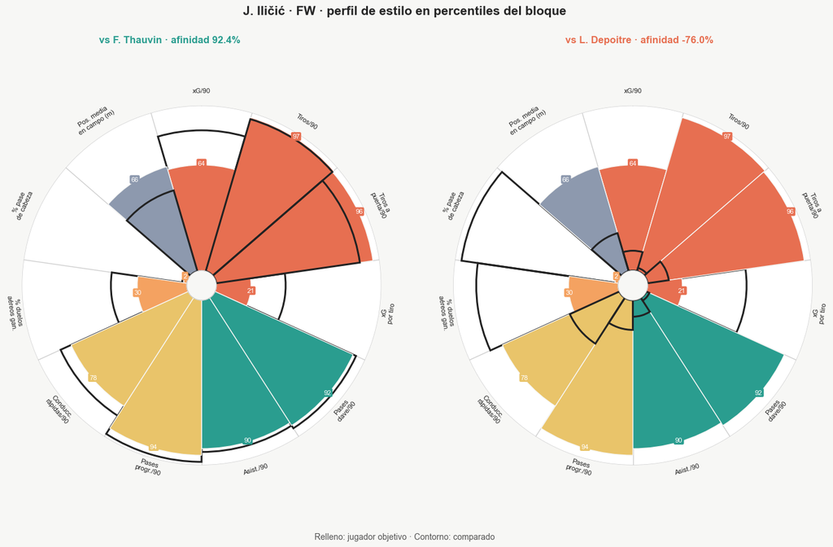

```python
b, anc = 'FW', 'J. Iličić'
i = sim_index[b]['pos'][anc]
arq = sim_index[b]['meta'].iloc[i]['archetype']
cos = cosine_similarity(sim_index[b]['X'][i:i+1], sim_index[b]['X'])[0]
regs = set(df.loc[df['meets_900min'], 'player_id'])
cand = sim_index[b]['meta'].reset_index(drop=True).assign(afin=(cos * 100).round(1))
cand = cand[(cand['archetype'] != arq) & (cand['player_id'].isin(regs))].sort_values('afin')

print(cand.head(8)[['short_name', 'archetype', 'afin']].to_string(index=False))
contraste = cand.iloc[0]['short_name']
panel_fichas('J. Iličić', 'F. Thauvin', contraste);
```

El panel resume en una imagen lo que el motor calcula y por qué es fiable. A la izquierda, Iličić y Thauvin —los dos perfiles más afines del bloque de delanteros— se superponen casi gajo a gajo: ambos puntúan muy alto en tiro, pases clave, asistencias y conducción, y bajo en juego aéreo y referencia. Su afinidad del 92 % no es una abstracción del espacio de componentes, sino esta coincidencia de forma, visible directamente sobre las métricas de estilo. A la derecha, el mismo Iličić frente al delantero referencia más opuesto invierte la figura: el contorno se hunde donde el relleno crece y domina donde el relleno cede, reflejando una afinidad fuertemente negativa. La comparación demuestra que la medida no solo agrupa lo semejante, sino que ordena también lo contrario, condición de toda métrica de similitud útil.

Que el perfil más divergente de un delantero creativo sea, de forma sistemática, un delantero de referencia confirma desde la similitud el eje que el agrupamiento ya había identificado como principal en el bloque ofensivo. La capa descriptiva y la de medición describen, por tanto, la misma estructura: una valida a la otra. La ficha comparativa cierra así el sistema por el lado del usuario, traduciendo la afinidad numérica al lenguaje visual con el que un cuerpo técnico evalúa perfiles, sin perder el anclaje en el estilo que define al proyecto.

## Cierre

Este notebook ha completado la columna vertebral del proyecto. A partir de la capa Gold de métricas por noventa minutos, construida íntegramente desde el evento crudo de Wyscout, se ha levantado un sistema de scouting en dos capas. La primera, descriptiva, segmenta a los jugadores de cada bloque posicional en doce arquetipos de estilo mediante reducción de dimensionalidad y agrupamiento, estables al remuestreo y libres de sesgo de liga. La segunda, de medición, sitúa a cada jugador en un espacio continuo de estilo y permite recuperar a sus semejantes por afinidad del coseno, acotando las recomendaciones por edad, liga y valor de mercado para sustentar consultas reales como la sustitución de una baja ajustada a presupuesto o la detección de oportunidades de mercado.

El hilo metodológico que recorre el trabajo es la distinción entre estilo y calidad y la naturaleza continua del primero: el fútbol no se organiza en tipos discretos y aislados, sino en un espectro de perfiles que se solapan, y el sistema lo refleja combinando una capa de etiquetas interpretables con una capa de coordenadas continuas. Sus limitaciones quedan explícitas —una única temporada y unas métricas de evento sin datos de seguimiento, que no capturan el movimiento sin balón ni la intensidad física— y trazan las extensiones naturales del proyecto: el modelado de perfiles híbridos mediante agrupamiento blando, la incorporación de más temporadas para estudiar la evolución de los jugadores y la integración de datos de tracking. El resultado es una herramienta que prioriza decisiones de scouting de forma transparente, dejando el juicio final al analista.

```python
# Persistencia del motor de similitud
joblib.dump({
    'sim_index': sim_index,
    'blocks': BLOCKS,
    'names': NAMES,
    'desc_cols': DESC_COLS,
}, ARTIFACTS / "similarity_engine.joblib")

print("Motor guardado en", (ARTIFACTS / "similarity_engine.joblib").relative_to(Path.cwd().parents[0]))
for b in BLOCKS:
    n, d = sim_index[b]['X'].shape
    print(f"  {b}: {n} jugadores en espacio {d}-D")
```

```
Motor guardado en models/clustering/similarity_engine.joblib
  GK: 121 jugadores en espacio 5-D
  DF: 603 jugadores en espacio 17-D
  MD: 590 jugadores en espacio 17-D
  FW: 320 jugadores en espacio 17-D
```